# Impact of HIV Infection, Immune Status, and Integrase Inhibitor-Based Antiretroviral Therapy on the Gut Microbiota in Men Who Have Sex with Men With and Without HIV

```r
library(ANCOMBC)
library(SummarizedExperiment)
library(TreeSummarizedExperiment)
library(ggpubr)
library(ggrepel)
library(phyloseq)
library(vegan)
library(ape)
library(rstatix)
library(tidyverse)
```

# Analysis overview

This document reproduces the analyses used to characterize gut microbiota composition and predicted functional profiles in men who have sex with men (MSM) with and without HIV. The study design and participant characteristics are summarized in **Figure 1** and **Table 1** of the manuscript. The analyses evaluate HIV status, immune status, and exposure to integrase strand transfer inhibitor (INSTI)-based regimens.

## Raw-read processing

Raw sequencing reads are publicly available from the European Nucleotide Archive (ENA) under project accession **PRJEB84358** and therefore are not distributed with this repository. After downloading the reads, place them in `data/raw_reads/` before running the command below. Raw 16S rRNA gene sequencing reads were processed with the nf-core/ampliseq pipeline (version 2.9.0), using the SILVA 138 reference taxonomy and PICRUSt2 functional prediction as described in the manuscript.

```bash
nextflow run nf-core/ampliseq -r 2.9.0 -profile singularity --max_cpus 22 \
    --input_folder "data/raw_reads" \
    --FW_primer TACGGGNGGCWGCAG --RV_primer GACTACHVGGGTATCTAATCC \
    --metadata "data/sample_metadata.tsv" \
    --outdir "data/ampliseq_results" \
    --trunclenf 270 --trunclenr 215 \
    --vsearch_cluster \
    --filter_ssu "bac" \
    --qiime_ref_taxonomy silva=138 \
    --metadata_category "group" \
    --metadata_category_barplot "group" \
    --picrust \
    --diversity_rarefaction_depth 25000 \
    --skip_dada_taxonomy \
    --skip_dada_addspecies
```

## Analysis metadata

The metadata are read once for the genus, KO, and EC analyses. The nf-core/ampliseq alpha-diversity outputs and phyloseq object already contain these columns, so their embedded metadata are used directly without an additional join. `ID` identifies each sample, `pid` identifies the participant, `timepoint` identifies the sampling period, `group` contains the group code, and `group_label` contains the corresponding manuscript label.

```r
metadata <- read_tsv("data/sample_metadata.tsv")

group_levels <- c("prePEP_HIV-", "postPEP_HIV-",
  "naive_HIV+", "shortART_HIV+", "longART_HIV+")

group_label_levels <- c("prePEP", "postPEP",
  "HIV+ lowCD4 preART", "HIV+ lowCD4 postART", "HIV+ highCD4 postART")

timepoint_levels <- c("pre", "post")

metadata <- metadata |>
  mutate(
    timepoint = factor(timepoint, levels = timepoint_levels),
    group = factor(group, levels = group_levels))
```

# Helper functions

The following functions prepare concise taxonomic and KEGG ortholog labels for figures and rendered result tables.

## Function to clean taxon names

```r
clean_taxon_name <- function(x, add_rank = FALSE) {
  bad_terms <- c("", NA, "__", "unclassified", "unknown", "metagenome")

  clean_one <- function(s) {
    parts <- strsplit(s, ";", fixed = TRUE)[[1]]
    parts <- trimws(parts)

    get_rank <- function(prefix) {
      hit <- parts[grepl(paste0("^", prefix, "__"), parts)]
      if (length(hit) == 0) return(NA_character_)
      sub(paste0("^", prefix, "__"), "", hit[1])
    }

    ranks <- c(
      genus  = get_rank("g"),
      family = get_rank("f"),
      order  = get_rank("o"),
      class  = get_rank("c"),
      phylum = get_rank("p")
    )

    is_bad <- function(z) {
      is.na(z) || z %in% bad_terms || grepl("^_+$", z)
    }

    clean_text <- function(z) {
      z <- gsub("_", " ", z)
      z <- gsub("\\[|\\]", "", z)
      trimws(z)
    }

    wrap_first_word <- function(z) {
  parts <- strsplit(z, " ")[[1]]
  if (length(parts) > 1) {
    paste(c(parts[1], paste(parts[-1], collapse = " ")), collapse = "\n")
  } else {
    z
  }
}

    genus  <- ranks["genus"]
    family <- ranks["family"]

    fallback_rank <- function() {
      for (nm in c("family", "order", "class", "phylum")) {
        if (!is_bad(ranks[nm]) && tolower(ranks[nm]) != "uncultured") {
          return(list(value = unname(ranks[nm]), rank = nm))
        }
      }
      list(value = "Unclassified Bacteria", rank = "none")
    }

    # missing genus
    if (is_bad(genus)) {
      fb <- fallback_rank()
      out <- clean_text(fb$value)

      if (add_rank && fb$rank != "none") {
        out <- paste0(out, " (", fb$rank, ")")
      }
      return(wrap_first_word(out))
    }

    genus_low <- tolower(genus)

    # genus explicitly uncultured
    if (genus_low == "uncultured") {
      fb <- fallback_rank()
      return(wrap_first_word(paste0(clean_text(fb$value), " (uncultured)")))
    }

    # placeholder/code-like genus names: prefix with family if available
    placeholder_like <- grepl(
      "^(UCG-[0-9A-Z]+|CAG-[0-9A-Z]+|DTU[0-9A-Z]+|RF39|TM7x|UBA[0-9]+|NK[0-9A-Z]+_group|NC[0-9A-Z]+_group|ND[0-9A-Z]+_group|FCS[0-9A-Z]+_group)$",
      genus
    )

    if (!is_bad(family) && placeholder_like) {
      return(wrap_first_word(clean_text(paste(family, genus))))
    }

    wrap_first_word(clean_text(genus))
  }

  vapply(x, clean_one, character(1))
}
```

## Function to clean KO names

```r
make_ko_label <- function(KO, description) {
  x <- trimws(description)

  # Rule 1: hide uncharacterized proteins
  if (grepl("uncharacterized protein", x, ignore.case = TRUE)) {
    return(NA_character_)
  }

  # Remove EC annotation at the end
  x <- gsub("\\s*\\[EC:[^]]*\\]", "", x)
  x <- trimws(x)

  # Keep only text before the first semicolon
  left <- sub(";.*$", "", x)
  left <- trimws(left)

  # Remove leading KO if present
  left <- sub(paste0("^", KO, "\\s*"), "", left)
  left <- trimws(left)

  # If nothing remains after removing KO, fall back to KO
  if (left == "") {
    return(KO)
  }

  # Split aliases
  aliases <- trimws(strsplit(left, ",", fixed = TRUE)[[1]])
  aliases <- aliases[aliases != ""]

  # Filter out bad aliases
  is_bad_alias <- function(a, KO) {
    grepl("^E\\d+(\\.\\d+)*[A-Z]?$", a) ||      # EC-like token, e.g. E1.1.1.40 or E4.2.1.2A
      grepl("^TC\\.", a) ||                     # TC.* code
      grepl("^K\\d{5}$", a) ||                  # repeated KO
      identical(a, KO)
  }

  aliases <- aliases[!vapply(aliases, is_bad_alias, logical(1), KO = KO)]

  # If any usable alias remains, use the first one
  if (length(aliases) > 0) {
    return(aliases[1])
  }

  # Otherwise use KO
  KO
}
```

## Functions for input validation and displayed results

```r
align_metadata <- function(feature_matrix, metadata) {
  sample_ids <- colnames(feature_matrix)
  metadata_index <- match(sample_ids, metadata[["ID"]])

  if (anyNA(metadata_index)) {
    stop("Some abundance-table samples are absent from the sample metadata.")
  }

  aligned_metadata <- metadata[metadata_index, , drop = FALSE]
  stopifnot(identical(sample_ids, as.character(aligned_metadata[["ID"]])))
  DataFrame(aligned_metadata)
}

extract_permanova <- function(result, comparison) {
  tibble(
    comparison = comparison,
    R2 = result$R2[1],
    p_value = result$`Pr(>F)`[1]
  )
}
```

# Alpha diversity

Alpha diversity was evaluated using the number of observed amplicon sequence variants (ASVs) and the Shannon diversity index. Cross-sectional comparisons used the Kruskal–Wallis test followed by pairwise Mann–Whitney U tests with Benjamini–Hochberg correction, while longitudinal comparisons used paired Wilcoxon signed-rank tests (**Figure 2A–F**).

```r
colours_vector <- c("prePEP_HIV-" = "darkolivegreen1",
                  "postPEP_HIV-" = "darkseagreen",
                  "naive_HIV+" = "thistle1",
                  "shortART_HIV+" = "lightpink1",
                  "longART_HIV+" = "hotpink1")
colours_vector_label <- c("prePEP" = "darkolivegreen1",
                  "postPEP" = "darkseagreen",
                  "HIV+ lowCD4 preART" = "thistle1",
                  "HIV+ lowCD4 postART" = "lightpink1",
                  "HIV+ highCD4 postART" = "hotpink1")
```

## Observed features

```r
obs <- read_tsv("data/alpha_observed_features.tsv", comment = "#") |>
    dplyr::rename(ID = id) |>
    mutate(group = factor(group, levels = group_levels),
           timepoint = factor(timepoint, levels = c("pre", "post")))
```

### Baseline groups (Figure 2A)

Observed features were compared among the three independent baseline groups.

```r
# Subset data
obs_baseline <- obs |>
    filter(timepoint == "pre" | group == "longART_HIV+") |>
    select(ID, group, timepoint, observed_features)
# Check sample size per group
obs_baseline |>
  dplyr::count(group)
```

| group | n |
| --- | --- |
| prePEP_HIV- | 22 |
| naive_HIV+ | 21 |
| longART_HIV+ | 17 |

```r
# Kruskal–Wallis test across baseline groups
kw_obs <- obs_baseline |>
  kruskal_test(observed_features ~ group)

kw_obs
```

|  | .y. | n | statistic | df | p | method |
| --- | --- | --- | --- | --- | --- | --- |
| 1 | observed_features | 60 | 14.47315 | 2 | 0.00072 | Kruskal-Wallis |

```r
# Post-hoc pairwise Mann–Whitney if Kruskal–Wallis is significant
pairwise_res <- pairwise.wilcox.test(
  x = obs_baseline$observed_features,
  g = obs_baseline$group,
  p.adjust.method = "BH"
)

pairwise_obs_all <- as.data.frame(as.table(pairwise_res$p.value)) |>
  dplyr::rename(group1 = Var1, group2 = Var2, p.adj = Freq) |>
  filter(!is.na(p.adj)) |>
  mutate(
    label = ifelse(
      p.adj < 0.001,
      "p < 0.001",
      paste0("p = ", sprintf("%.3f", p.adj))
    )
  )

pairwise_obs_all |> select(group1, group2, p.adj)
```

| group1 | group2 | p.adj |
| --- | --- | --- |
| naive_HIV+ | prePEP_HIV- | 1.162654e-01 |
| longART_HIV+ | prePEP_HIV- | 8.321813e-05 |
| longART_HIV+ | naive_HIV+ | 6.861947e-02 |

```r
ymax <- max(obs_baseline$observed_features, na.rm = TRUE)

pairwise_res <- pairwise_obs_all |>
  filter(p.adj < 0.05) |>
  mutate(y.position = 400)
```

Graphics:

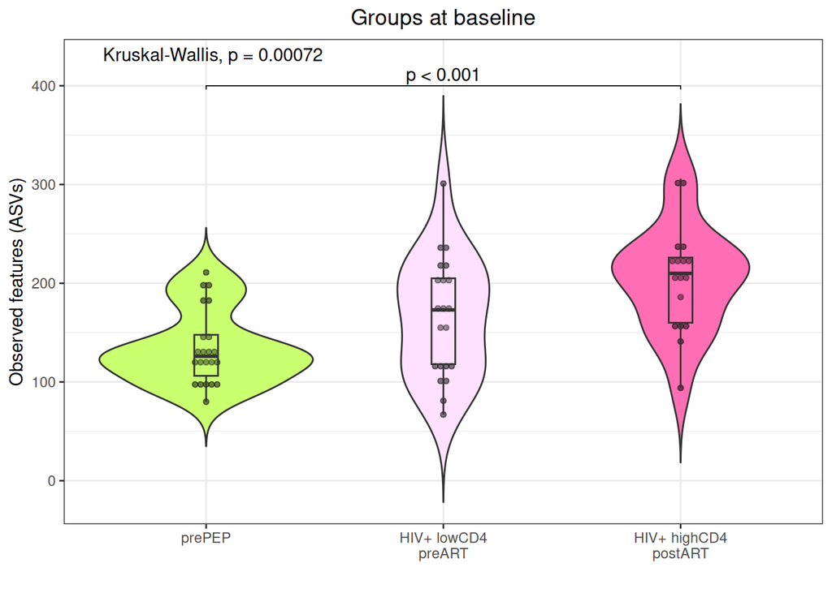

```r
pA1 <- obs_baseline |>
    ggplot(aes(x = group, y = observed_features, fill = group)) +
  geom_violin(trim = FALSE) +
  geom_dotplot(
    binaxis = "y",
    stackdir = "center",
    dotsize = 0.5,
    fill = "black",
    alpha = 0.5
  ) +
  geom_boxplot(width = 0.1, alpha = 0.2, outlier.shape = NA) +
  scale_fill_manual(values = colours_vector) +
  scale_x_discrete(labels = c(
    "prePEP_HIV-"  = "prePEP",
    "naive_HIV+"    = "HIV+ lowCD4\npreART",
    "longART_HIV+" = "HIV+ highCD4\npostART"
  )) +
  labs(
    title = "Groups at baseline",
    x = "",
    y = "Observed features (ASVs)"
  ) +
  theme_bw() +
  theme(legend.position = "none",
        plot.title = element_text(hjust = 0.5)) +
  stat_compare_means(
    method = "kruskal.test",
    label.y = 425,
    label.x = 0.75
  ) +
    stat_pvalue_manual(
    pairwise_res,
    label = "label",
    tip.length = 0.01
  )
pA1
```

### Short-term PEP exposure (Figure 2B)

Pre- and post-PEP samples were paired by participant before the Wilcoxon signed-rank test.

```r
obs_pep <- obs |>
  filter(group %in% c("prePEP_HIV-", "postPEP_HIV-")) |>
  select(pid, group, observed_features) |>
  pivot_wider(names_from = group, values_from = observed_features) |>
  drop_na()

obs_pep_test <- wilcox.test(
  obs_pep$`prePEP_HIV-`, obs_pep$`postPEP_HIV-`, paired = TRUE
)
tibble(comparison = "prePEP vs postPEP", n_pairs = nrow(obs_pep),
       statistic = unname(obs_pep_test$statistic), p_value = obs_pep_test$p.value)
```

| comparison | n_pairs | statistic | p_value |
| --- | --- | --- | --- |
| prePEP vs postPEP | 22 | 167.5 | 0.1897101 |

Graphics:

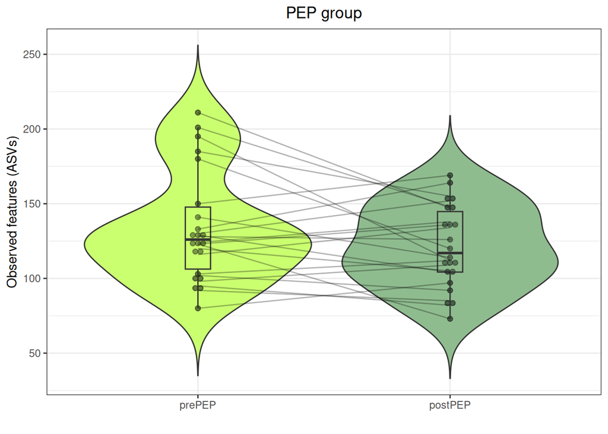

```r
pA2 <- obs |>
    filter(group %in% c("prePEP_HIV-", "postPEP_HIV-")) |>
    ggplot(aes(x = group, y = observed_features, fill = group)) +
  geom_violin(trim = FALSE) +
  geom_dotplot(
    binaxis = "y",
    stackdir = "center",
    dotsize = 0.75,
    fill = "black",
    alpha = 0.5
  ) +
  geom_boxplot(width = 0.1, alpha = 0.2, outlier.shape = NA) +
  geom_line(aes(group = pid), alpha = 0.3) +
  scale_fill_manual(values = colours_vector) +
  scale_x_discrete(labels = c(
    "prePEP_HIV-"  = "prePEP",
    "postPEP_HIV-"  = "postPEP"
  )) +
  labs(
    title = "PEP group",
    x = "",
    y = "Observed features (ASVs)"
  ) +
  theme_bw() +
  theme(legend.position = "none",
        plot.title = element_text(hjust = 0.5))
pA2
```

### ART initiation in participants with low CD4 counts (Figure 2C)

Pre- and post-ART samples were paired by participant identifier.

```r
keep_pids_obs <- obs |>
    filter(group %in% c("naive_HIV+", "shortART_HIV+")) |>
    dplyr::count(pid) |>
    filter(n == 2) |>
    pull(pid)

obs_art <- obs |>
    filter(group %in% c("naive_HIV+", "shortART_HIV+")) |>
    filter(pid %in% keep_pids_obs) |>
    select(pid, group, observed_features) |>
    pivot_wider(names_from = group, values_from = observed_features) |>
    drop_na()

obs_art_test <- wilcox.test(
  obs_art$`naive_HIV+`, obs_art$`shortART_HIV+`, paired = TRUE
)
tibble(comparison = "low-CD4 preART vs postART", n_pairs = nrow(obs_art),
       statistic = unname(obs_art_test$statistic), p_value = obs_art_test$p.value)
```

| comparison | n_pairs | statistic | p_value |
| --- | --- | --- | --- |
| low-CD4 preART vs postART | 10 | 36 | 0.4316406 |

Graphics:

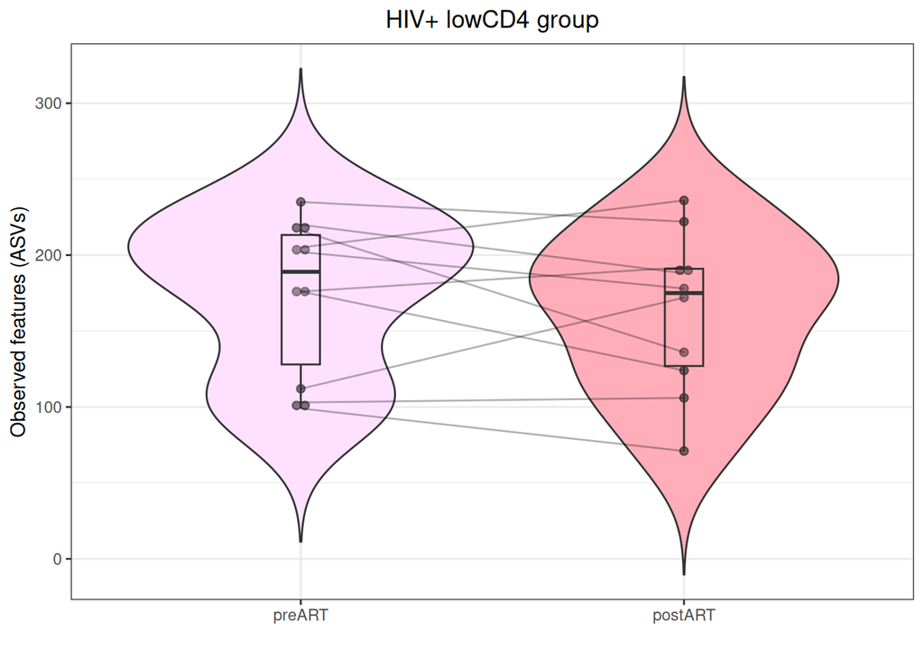

```r
pA3 <- obs |>
    filter(group %in% c("naive_HIV+", "shortART_HIV+")) |>
    filter(pid %in% keep_pids_obs) |>
    ggplot(aes(x = group, y = observed_features, fill = group)) +
  geom_line(alpha = 0.3) +
  geom_violin(trim = FALSE) +
  geom_dotplot(
    binaxis = "y",
    stackdir = "center",
    dotsize = 1,
    fill = "black",
    alpha = 0.5
  ) +
  geom_boxplot(width = 0.1, alpha = 0.2, outlier.shape = NA) +
  geom_line(aes(group = pid), alpha = 0.3) +
  scale_fill_manual(values = colours_vector) +
  scale_x_discrete(labels = c(
    "naive_HIV+"  = "preART",
    "shortART_HIV+"  = "postART"
  )) +
  labs(
    title = "HIV+ lowCD4 group",
    x = "",
    y = "Observed features (ASVs)"
  ) +
  theme_bw() +
  theme(legend.position = "none",
        plot.title = element_text(hjust = 0.5))
pA3
```

## Shannon diversity index

```r
shannon <- read_tsv("data/alpha_shannon.tsv", comment = "#") |>
    dplyr::rename(ID = id) |>
    mutate(group = factor(group, levels = group_levels),
           timepoint = factor(timepoint, levels = c("pre", "post")))
```

### Baseline groups (Figure 2D)

Shannon diversity was compared among the three independent baseline groups.

```r
# Subset data
shannon_baseline <- shannon |>
    filter(group %in% c("prePEP_HIV-", "naive_HIV+", "longART_HIV+")) |>
    select(ID, group, shannon_entropy)
# Check sample size per group
shannon_baseline |>
  dplyr::count(group)
```

| group | n |
| --- | --- |
| prePEP_HIV- | 22 |
| naive_HIV+ | 21 |
| longART_HIV+ | 17 |

```r
# Kruskal–Wallis test across baseline groups
kw_shannon <- shannon_baseline |>
  kruskal_test(shannon_entropy ~ group)

kw_shannon
```

|  | .y. | n | statistic | df | p | method |
| --- | --- | --- | --- | --- | --- | --- |
| 1 | shannon_entropy | 60 | 10.56062 | 2 | 0.00509 | Kruskal-Wallis |

```r
# Post-hoc pairwise Mann–Whitney if Kruskal–Wallis is significant
pairwise_res <- pairwise.wilcox.test(
  x = shannon_baseline$shannon_entropy,
  g = shannon_baseline$group,
  p.adjust.method = "BH"
)

pairwise_shannon_all <- as.data.frame(as.table(pairwise_res$p.value)) |>
  dplyr::rename(group1 = Var1, group2 = Var2, p.adj = Freq) |>
  filter(!is.na(p.adj)) |>
  mutate(
    label = ifelse(
      p.adj < 0.001,
      "p < 0.001",
      paste0("p = ", sprintf("%.3f", p.adj))
    )
  )

pairwise_shannon_all |> select(group1, group2, p.adj)
```

| group1 | group2 | p.adj |
| --- | --- | --- |
| naive_HIV+ | prePEP_HIV- | 0.16399794 |
| longART_HIV+ | prePEP_HIV- | 0.00263891 |
| longART_HIV+ | naive_HIV+ | 0.08951205 |

```r
ymax <- max(shannon_baseline$shannon_entropy, na.rm = TRUE)

pairwise_res <- pairwise_shannon_all |>
  filter(p.adj < 0.05) |>
  mutate(y.position = 7.6)
```

Graphics:

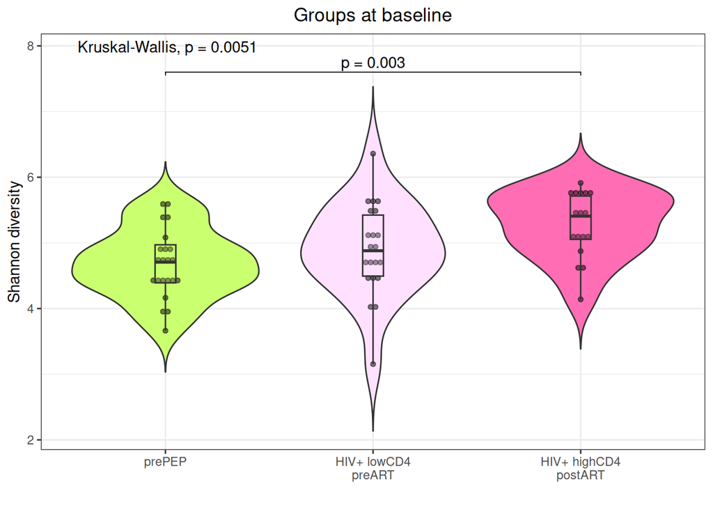

```r
pB1 <- shannon_baseline |>
    ggplot(aes(x = group, y = shannon_entropy, fill = group)) +
  geom_violin(trim = FALSE) +
  geom_dotplot(
    binaxis = "y",
    stackdir = "center",
    dotsize = 0.5,
    fill = "black",
    alpha = 0.5
  ) +
  geom_boxplot(width = 0.1, alpha = 0.2, outlier.shape = NA) +
  scale_fill_manual(values = colours_vector) +
  scale_x_discrete(labels = c(
    "prePEP_HIV-"  = "prePEP",
    "naive_HIV+"    = "HIV+ lowCD4\npreART",
    "longART_HIV+" = "HIV+ highCD4\npostART"
  )) +
  labs(
    title = "Groups at baseline",
    x = "",
    y = "Shannon diversity"
  ) +
  theme_bw() +
  theme(legend.position = "none",
        plot.title = element_text(hjust = 0.5)) +
  stat_compare_means(
    method = "kruskal.test",
    label.y = 7.9,
    label.x = 0.75
  ) +
    stat_pvalue_manual(
    pairwise_res,
    label = "label",
    tip.length = 0.01
  )
pB1
```

### Short-term PEP exposure (Figure 2E)

Pre- and post-PEP samples were paired by participant before the Wilcoxon signed-rank test.

```r
shannon_pep <- shannon |>
  filter(group %in% c("prePEP_HIV-", "postPEP_HIV-")) |>
  select(pid, group, shannon_entropy) |>
  pivot_wider(names_from = group, values_from = shannon_entropy) |>
  drop_na()

shannon_pep_test <- wilcox.test(
  shannon_pep$`prePEP_HIV-`, shannon_pep$`postPEP_HIV-`, paired = TRUE
)
tibble(comparison = "prePEP vs postPEP", n_pairs = nrow(shannon_pep),
       statistic = unname(shannon_pep_test$statistic), p_value = shannon_pep_test$p.value)
```

| comparison | n_pairs | statistic | p_value |
| --- | --- | --- | --- |
| prePEP vs postPEP | 22 | 165 | 0.2221074 |

Graphics:

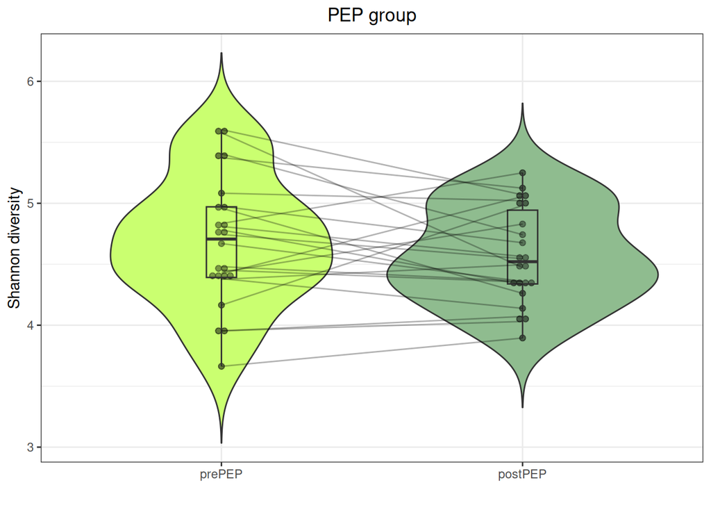

```r
pB2 <- shannon |>
    filter(group %in% c("prePEP_HIV-", "postPEP_HIV-")) |>
    ggplot(aes(x = group, y = shannon_entropy, fill = group)) +
  geom_violin(trim = FALSE) +
  geom_dotplot(
    binaxis = "y",
    stackdir = "center",
    dotsize = 0.75,
    fill = "black",
    alpha = 0.5
  ) +
  geom_boxplot(width = 0.1, alpha = 0.2, outlier.shape = NA) +
  geom_line(aes(group = pid), alpha = 0.3) +
  scale_fill_manual(values = colours_vector) +
  scale_x_discrete(labels = c(
    "prePEP_HIV-"  = "prePEP",
    "postPEP_HIV-"  = "postPEP"
  )) +
  labs(
    title = "PEP group",
    x = "",
    y = "Shannon diversity"
  ) +
  theme_bw() +
  theme(legend.position = "none",
        plot.title = element_text(hjust = 0.5))
pB2
```

### ART initiation in participants with low CD4 counts (Figure 2F)

Pre- and post-ART samples were paired by participant identifier.

```r
keep_pids_shannon <- shannon |>
    filter(group %in% c("naive_HIV+", "shortART_HIV+")) |>
    dplyr::count(pid) |>
    filter(n == 2) |>
    pull(pid)

shannon_art <- shannon |>
    filter(group %in% c("naive_HIV+", "shortART_HIV+")) |>
    filter(pid %in% keep_pids_shannon) |>
    select(pid, group, shannon_entropy) |>
    pivot_wider(names_from = group, values_from = shannon_entropy) |>
    drop_na()

shannon_art_test <- wilcox.test(
  shannon_art$`naive_HIV+`, shannon_art$`shortART_HIV+`, paired = TRUE
)
tibble(comparison = "low-CD4 preART vs postART",
       n_pairs = nrow(shannon_art),
       statistic = unname(shannon_art_test$statistic),
       p_value = shannon_art_test$p.value)
```

| comparison | n_pairs | statistic | p_value |
| --- | --- | --- | --- |
| low-CD4 preART vs postART | 10 | 32 | 0.6953125 |

Graphics:

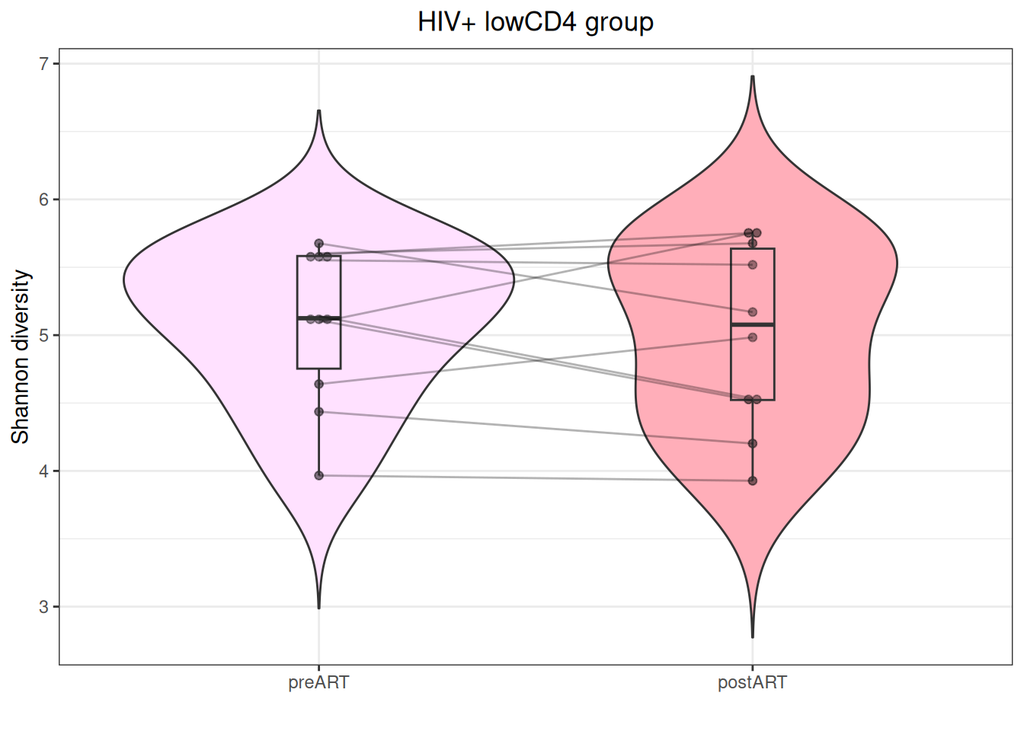

```r
pB3 <- shannon |>
    filter(group %in% c("naive_HIV+", "shortART_HIV+")) |>
    filter(pid %in% keep_pids_shannon) |>
    ggplot(aes(x = group, y = shannon_entropy, fill = group)) +
  geom_violin(trim = FALSE) +
  geom_dotplot(
    binaxis = "y",
    stackdir = "center",
    dotsize = 1,
    fill = "black",
    alpha = 0.5
  ) +
  geom_boxplot(width = 0.1, alpha = 0.2, outlier.shape = NA) +
  geom_line(aes(group = pid), alpha = 0.3) +
  scale_fill_manual(values = colours_vector) +
  scale_x_discrete(labels = c(
    "naive_HIV+"  = "preART",
    "shortART_HIV+"  = "postART"
  )) +
  labs(
    title = "HIV+ lowCD4 group",
    x = "",
    y = "Shannon diversity"
  ) +
  theme_bw() +
  theme(legend.position = "none",
        plot.title = element_text(hjust = 0.5))
pB3
```

## Final figure (alpha diversity)

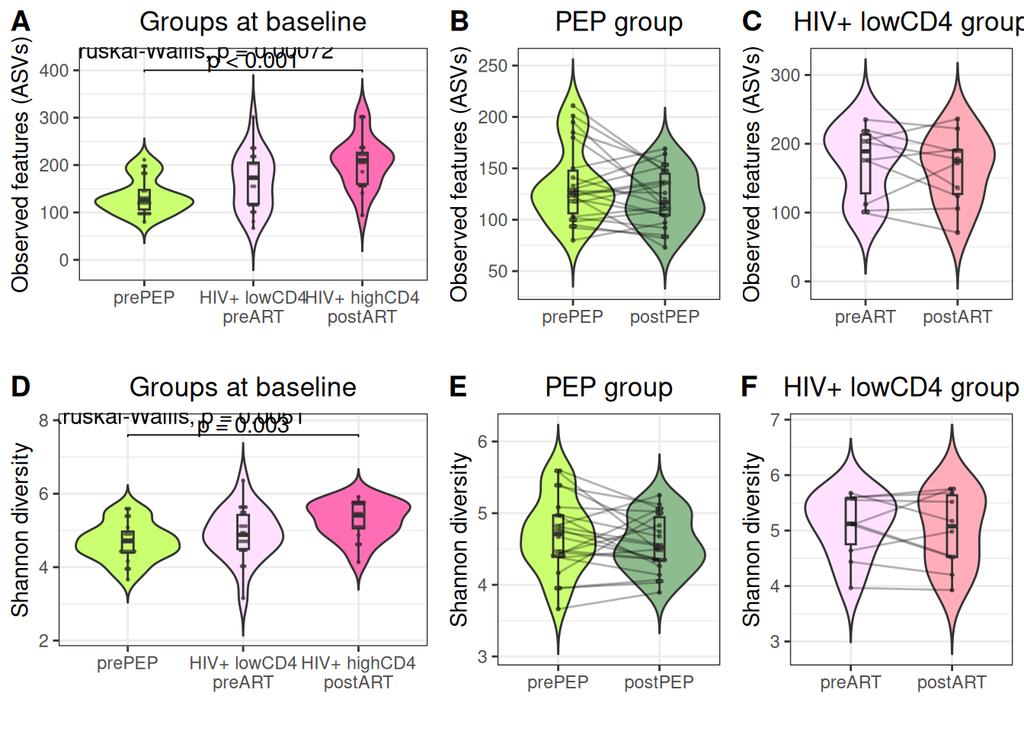

```r
# svg("figures/alpha_diversity.svg", width = 10.5, height = 7.5)
ggpubr::ggarrange(
    pA1, pA2, pA3, pB1, pB2, pB3,
    ncol = 3, nrow = 2,
    widths = c(1.5, 1, 1),
    labels = c("A", "B", "C", "D", "E", "F")
)
```

```r
# dev.off()
```

# Beta diversity

Beta diversity was assessed using principal coordinate analysis (PCoA) of weighted UniFrac distances. Between-group comparisons used PERMANOVA with 10,000 permutations. Longitudinal comparisons restricted permutations within participants to account for paired sampling (**Figure 3A–E**).

```r
# Load phyloseq data
physeq_data <- readRDS("data/qiime2_phyloseq.rds")

sample_data(physeq_data)$timepoint <- factor(
  sample_data(physeq_data)$timepoint,
  levels = timepoint_levels)
sample_data(physeq_data)$group <- factor(
  sample_data(physeq_data)$group,
  levels = group_levels)
sample_data(physeq_data)$group_label <- factor(
  sample_data(physeq_data)$group_label,
  levels = group_label_levels)

# Read tree
tree_data <- read.tree("data/phylogenetic_tree.nwk")
# Add tree
physeq_data_tree <- merge_phyloseq(physeq_data, tree_data)
```

Statistics:

```r
sam <- data.frame(sample_data(physeq_data_tree))
sam
```

|  | group | pid | timepoint | group_label |
| --- | --- | --- | --- | --- |
| ARTIB17W0 | prePEP_HIV- | ARTIB17 | pre | prePEP |
| ARTIB17W4 | postPEP_HIV- | ARTIB17 | post | postPEP |
| ARTIB18W0 | prePEP_HIV- | ARTIB18 | pre | prePEP |
| ARTIB18W4 | postPEP_HIV- | ARTIB18 | post | postPEP |
| ARTIB19W0 | prePEP_HIV- | ARTIB19 | pre | prePEP |
| ARTIB19W4 | postPEP_HIV- | ARTIB19 | post | postPEP |
| ARTIB20W0 | prePEP_HIV- | ARTIB20 | pre | prePEP |
| ARTIB20W4 | postPEP_HIV- | ARTIB20 | post | postPEP |
| ARTIB21W0 | prePEP_HIV- | ARTIB21 | pre | prePEP |
| ARTIB21W4 | postPEP_HIV- | ARTIB21 | post | postPEP |

[output cut: 85 more lines]

## Weighted Unifrac

```r
wunifrac <- ordinate(physeq = physeq_data_tree, method = "PCoA", distance = "wunifrac")
pco1_var <- round(wunifrac$values$Relative_eig[1] * 100, 1)
pco2_var <- round(wunifrac$values$Relative_eig[2] * 100, 1)
wunifrac_df <- data.frame(wunifrac$vectors) |>
    select(Axis.1, Axis.2) |>
    mutate(group_label = sample_data(physeq_data_tree)$group_label)
```

### All study groups (Figure 3A)

The global ordination displays all study groups.

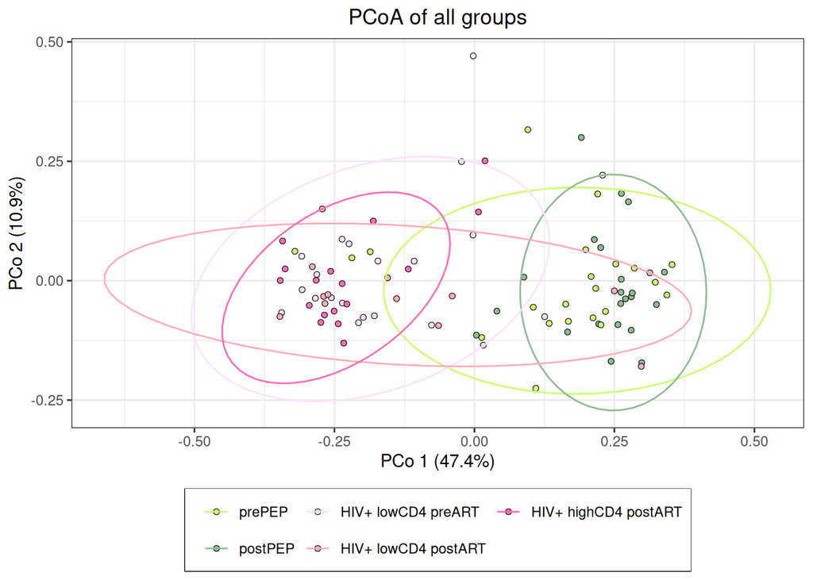

```r
f2A <- wunifrac_df |> ggplot(aes(x = Axis.1, y = Axis.2, fill = group_label, colour = group_label)) +
    geom_point(shape = 21, colour = "black", stroke = 0.3) +
    stat_ellipse() +
    scale_fill_manual(values = colours_vector_label) +
    scale_colour_manual(values = colours_vector_label) +
    labs (title = "PCoA of all groups",
          x = paste0("PCo 1 (", pco1_var, "%)"),
          y = paste0("PCo 2 (", pco2_var, "%)"),
          fill = "", colour = "") +
    theme_bw() +
    theme(legend.position = "bottom",
          legend.box.background = element_rect(color = "black"),
          plot.title = element_text(hjust = 0.5)) +
    guides(fill = guide_legend(nrow = 2))
f2A
```

### HIV status (Figure 3B)

HIV-negative participants before PEP were compared with ART-naive participants with HIV and low CD4 counts.

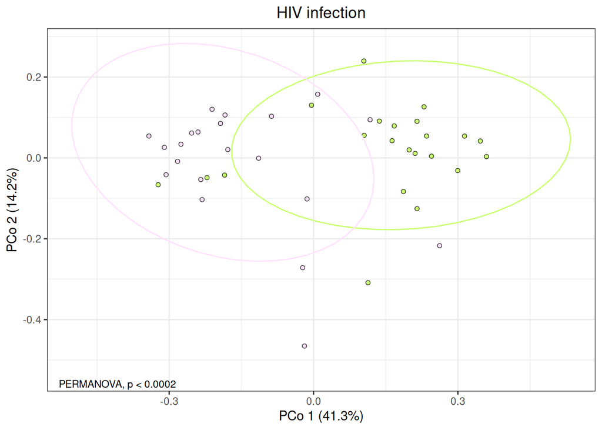

```r
physeq_data_tree_f2B <- subset_samples(physeq_data_tree,
                                       group_label %in% c("prePEP",
                                                    "HIV+ lowCD4 preART"))

wunifrac_f2B <- ordinate(physeq = physeq_data_tree_f2B, method = "PCoA", distance = "wunifrac")

pco1_var_f2B <- round(wunifrac_f2B$values$Relative_eig[1] * 100, 1)
pco2_var_f2B <- round(wunifrac_f2B$values$Relative_eig[2] * 100, 1)

wunifrac_df_f2B <- data.frame(wunifrac_f2B$vectors) |>
    select(Axis.1, Axis.2) |>
    mutate(group_label = sample_data(physeq_data_tree_f2B)$group_label)

f2B <- wunifrac_df_f2B |> ggplot(aes(x = Axis.1, y = Axis.2, fill = group_label, colour = group_label)) +
    geom_point(shape = 21, colour = "black", stroke = 0.3) +
    stat_ellipse() +
    scale_fill_manual(values = colours_vector_label) +
    scale_colour_manual(values = colours_vector_label) +
    labs (title = "HIV infection",
          x = paste0("PCo 1 (", pco1_var_f2B, "%)"),
          y = paste0("PCo 2 (", pco2_var_f2B, "%)"),
          fill = "", colour = "") +
    theme_bw() +
    theme(legend.position = "none",
          plot.title = element_text(hjust = 0.5)) +
    annotate("text", x = -Inf, y = -Inf,
         label = "PERMANOVA, p < 0.0002",
         hjust = -0.1, vjust = -0.5,
         size = 3) +
    scale_y_continuous(expand = expansion(mult = c(0.15, 0.05)))
f2B
```

Statistics:

```r
sam_f2B <- data.frame(sample_data(physeq_data_tree_f2B))
wunifrac_dist_f2B <- phyloseq::distance(physeq_data_tree_f2B, method = "wunifrac")
permanova_f2B <- adonis2(wunifrac_dist_f2B ~ group_label, data = sam_f2B, permutations = 10000)
permanova_f2B
```

|  | Df | SumOfSqs | R2 | F | Pr(>F) |
| --- | --- | --- | --- | --- | --- |
| Model | 1 | 0.9653547 | 0.1938228 | 9.857306 | 9.999e-05 |
| Residual | 41 | 4.0152493 | 0.8061772 | NA | NA |
| Total | 42 | 4.9806040 | 1.0000000 | NA | NA |

### Immune status (Figure 3C)

Participants with HIV and low CD4 counts after ART were compared with participants with HIV and high CD4 counts receiving ART.

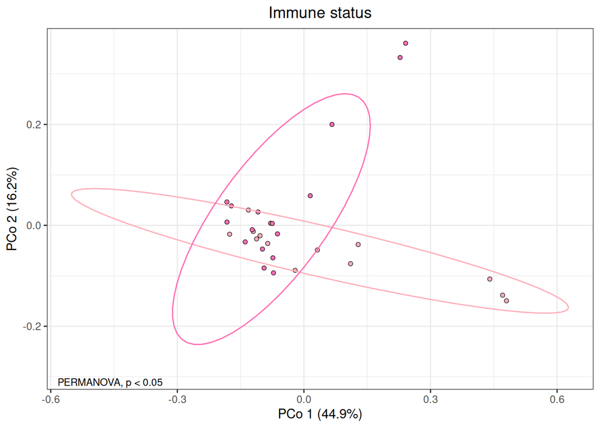

```r
physeq_data_tree_f2C <- subset_samples(physeq_data_tree,
                                       group_label %in% c("HIV+ lowCD4 postART",
                                                    "HIV+ highCD4 postART"))

wunifrac_f2C <- ordinate(physeq = physeq_data_tree_f2C, method = "PCoA", distance = "wunifrac")

pco1_var_f2C <- round(wunifrac_f2C$values$Relative_eig[1] * 100, 1)
pco2_var_f2C <- round(wunifrac_f2C$values$Relative_eig[2] * 100, 1)

wunifrac_df_f2C <- data.frame(wunifrac_f2C$vectors) |>
    select(Axis.1, Axis.2) |>
    mutate(group_label = sample_data(physeq_data_tree_f2C)$group_label)

f2C <- wunifrac_df_f2C |> ggplot(aes(x = Axis.1, y = Axis.2, fill = group_label, colour = group_label)) +
    geom_point(shape = 21, colour = "black", stroke = 0.3) +
    stat_ellipse() +
    scale_fill_manual(values = colours_vector_label) +
    scale_colour_manual(values = colours_vector_label) +
    labs (title = "Immune status",
          x = paste0("PCo 1 (", pco1_var_f2C, "%)"),
          y = paste0("PCo 2 (", pco2_var_f2C, "%)"),
          fill = "", colour = "") +
    theme_bw() +
    theme(legend.position = "none",
          plot.title = element_text(hjust = 0.5)) +
    annotate("text", x = -Inf, y = -Inf,
         label = "PERMANOVA, p < 0.05",
         hjust = -0.1, vjust = -0.5,
         size = 3) +
    scale_y_continuous(expand = expansion(mult = c(0.15, 0.05)))
f2C
```

Statistics:

```r
sam_f2C <- data.frame(sample_data(physeq_data_tree_f2C))
wunifrac_dist_f2C <- phyloseq::distance(physeq_data_tree_f2C, method = "wunifrac")
permanova_f2C <- adonis2(wunifrac_dist_f2C ~ group_label, data = sam_f2C, permutations = 10000)
permanova_f2C
```

|  | Df | SumOfSqs | R2 | F | Pr(>F) |
| --- | --- | --- | --- | --- | --- |
| Model | 1 | 0.2163272 | 0.09058117 | 2.788894 | 0.0259974 |
| Residual | 28 | 2.1718862 | 0.90941883 | NA | NA |
| Total | 29 | 2.3882134 | 1.00000000 | NA | NA |

### Short-term PEP exposure (Figure 3D)

The paired comparison evaluates changes from pre-PEP to post-PEP in HIV-negative participants.

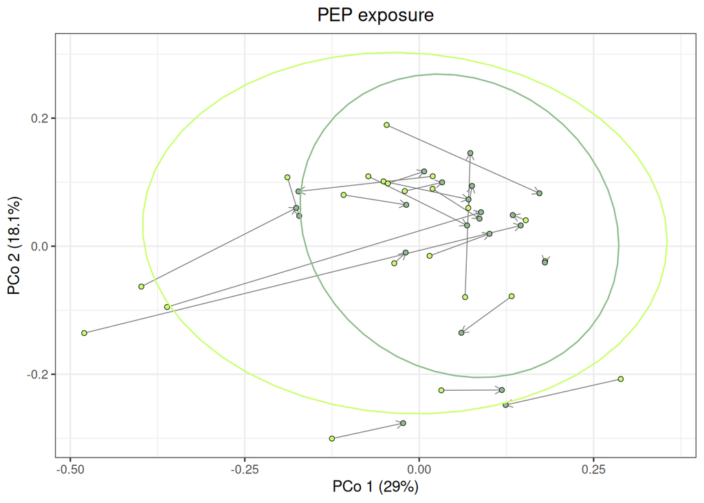

```r
physeq_data_tree_f2D <- subset_samples(physeq_data_tree,
                                       group_label %in% c("prePEP",
                                                    "postPEP"))

wunifrac_f2D <- ordinate(physeq = physeq_data_tree_f2D, method = "PCoA", distance = "wunifrac")

pco1_var_f2D <- round(wunifrac_f2D$values$Relative_eig[1] * 100, 1)
pco2_var_f2D <- round(wunifrac_f2D$values$Relative_eig[2] * 100, 1)

wunifrac_df_f2D <- data.frame(wunifrac_f2D$vectors) |>
    select(Axis.1, Axis.2) |>
    mutate(group_label = sample_data(physeq_data_tree_f2D)$group_label,
           pid = sample_data(physeq_data_tree_f2D)$pid,
           timepoint = sample_data(physeq_data_tree_f2D)$timepoint)

f2D <- wunifrac_df_f2D |> arrange(pid, timepoint) |>
    ggplot(aes(x = Axis.1, y = Axis.2, fill = group_label, colour = group_label)) +
    geom_path(aes(group = pid), colour = "grey50", linewidth = 0.3,
              arrow = arrow(length = unit(0.2, "cm"), type = "open")) +
    geom_point(shape = 21, colour = "black", stroke = 0.3) +
    stat_ellipse() +
    scale_fill_manual(values = colours_vector_label) +
    scale_colour_manual(values = colours_vector_label) +
    labs (title = "PEP exposure",
          x = paste0("PCo 1 (", pco1_var_f2D, "%)"),
          y = paste0("PCo 2 (", pco2_var_f2D, "%)"),
          fill = "", colour = "") +
    theme_bw() +
    theme(legend.position = "none",
          plot.title = element_text(hjust = 0.5))
f2D
```

Statistics:

```r
sam_f2D <- data.frame(sample_data(physeq_data_tree_f2D))
wunifrac_dist_f2D <- phyloseq::distance(physeq_data_tree_f2D, method = "wunifrac")
permanova_f2D <- with(sam_f2D, adonis2(wunifrac_dist_f2D ~ group_label,
                 data = sam_f2D, permutations = 10000, strata = pid))
permanova_f2D
```

|  | Df | SumOfSqs | R2 | F | Pr(>F) |
| --- | --- | --- | --- | --- | --- |
| Model | 1 | 0.109610 | 0.03065698 | 1.328315 | 0.03259674 |
| Residual | 42 | 3.465757 | 0.96934302 | NA | NA |
| Total | 43 | 3.575367 | 1.00000000 | NA | NA |

### ART initiation in participants with low CD4 counts (Figure 3E)

The paired comparison evaluates samples collected before and after ART initiation.

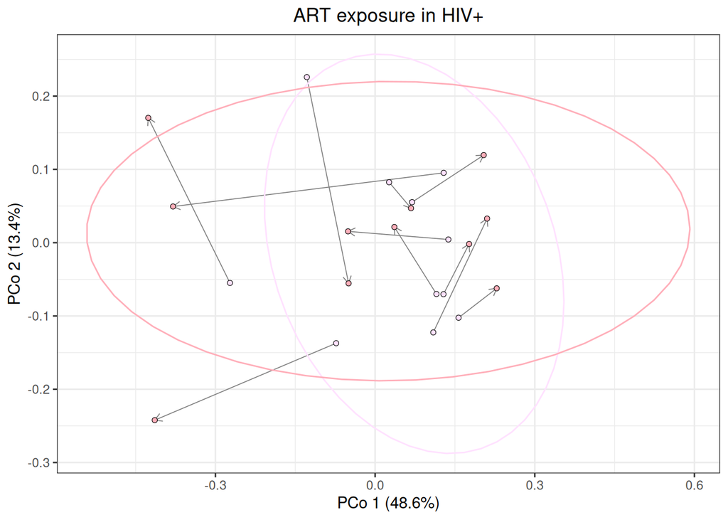

```r
paired_pids_f2E <- data.frame(sample_data(physeq_data_tree)) |>
  filter(group_label %in% c("HIV+ lowCD4 preART", "HIV+ lowCD4 postART")) |>
  dplyr::count(pid) |>
  filter(n == 2) |>
  pull(pid)

physeq_data_tree_f2E <- subset_samples(physeq_data_tree,
                                       group_label %in% c("HIV+ lowCD4 preART",
                                                    "HIV+ lowCD4 postART") & pid %in% paired_pids_f2E)

wunifrac_f2E <- ordinate(physeq = physeq_data_tree_f2E, method = "PCoA", distance = "wunifrac")

pco1_var_f2E <- round(wunifrac_f2E$values$Relative_eig[1] * 100, 1)
pco2_var_f2E <- round(wunifrac_f2E$values$Relative_eig[2] * 100, 1)

wunifrac_df_f2E <- data.frame(wunifrac_f2E$vectors) |>
    select(Axis.1, Axis.2) |>
    mutate(group_label = sample_data(physeq_data_tree_f2E)$group_label,
           pid = sample_data(physeq_data_tree_f2E)$pid,
           timepoint = sample_data(physeq_data_tree_f2E)$timepoint)

f2E <- wunifrac_df_f2E |> arrange(pid, timepoint) |>
    ggplot(aes(x = Axis.1, y = Axis.2, fill = group_label, colour = group_label)) +
    geom_path(aes(group = pid), colour = "grey50", linewidth = 0.3,
              arrow = arrow(length = unit(0.2, "cm"), type = "open")) +
    geom_point(shape = 21, colour = "black", stroke = 0.3) +
    stat_ellipse() +
    scale_fill_manual(values = colours_vector_label) +
    scale_colour_manual(values = colours_vector_label) +
    labs (title = "ART exposure in HIV+",
          x = paste0("PCo 1 (", pco1_var_f2E, "%)"),
          y = paste0("PCo 2 (", pco2_var_f2E, "%)"),
          fill = "", colour = "") +
    theme_bw() +
    theme(legend.position = "none",
          plot.title = element_text(hjust = 0.5))
f2E
```

Statistics:

```r
sam_f2E <- data.frame(sample_data(physeq_data_tree_f2E))
wunifrac_dist_f2E <- phyloseq::distance(physeq_data_tree_f2E, method = "wunifrac")
permanova_f2E <- with(sam_f2E, adonis2(wunifrac_dist_f2E ~ group_label, data = sam_f2E,
                                       permutations = 10000, strata = pid))
permanova_f2E
```

|  | Df | SumOfSqs | R2 | F | Pr(>F) |
| --- | --- | --- | --- | --- | --- |
| Model | 1 | 0.08503931 | 0.04688993 | 0.9839354 | 0.1748047 |
| Residual | 20 | 1.72855487 | 0.95311007 | NA | NA |
| Total | 21 | 1.81359419 | 1.00000000 | NA | NA |

```r
bind_rows(
  extract_permanova(permanova_f2B, "HIV status"),
  extract_permanova(permanova_f2C, "Immune status"),
  extract_permanova(permanova_f2D, "PEP exposure"),
  extract_permanova(permanova_f2E, "ART initiation in low-CD4 participants")
)
```

| comparison | R2 | p_value |
| --- | --- | --- |
| HIV status | 0.19382281 | 0.00009999 |
| Immune status | 0.09058117 | 0.02599740 |
| PEP exposure | 0.03065698 | 0.03259674 |
| ART initiation in low-CD4 participants | 0.04688993 | 0.17480469 |

### Final figure (beta diversity)

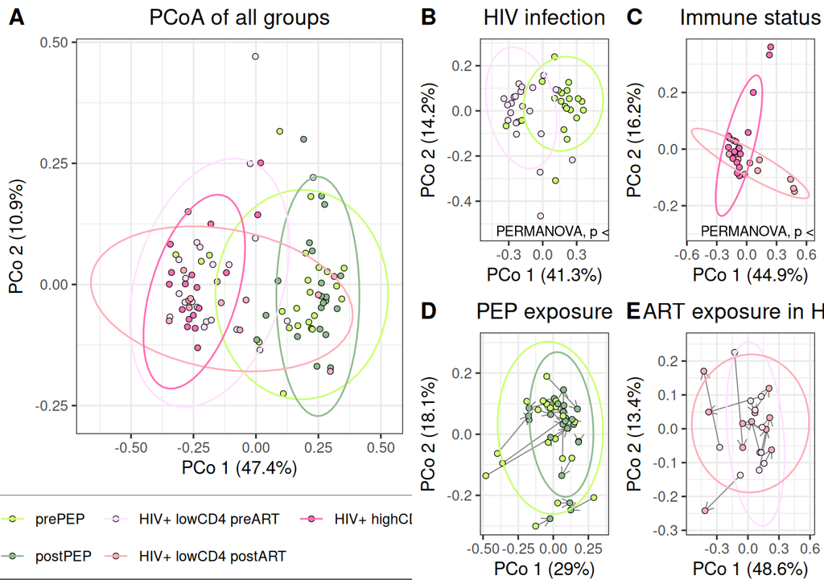

```r
# svg("figures/beta_diversity.svg", width = 10.5, height = 5.25)
right_panel <- ggpubr::ggarrange(
    f2B, f2C, f2D, f2E,
    ncol = 2, nrow = 2,
    labels = c("B", "C", "D", "E")
)

ggpubr::ggarrange(
    f2A, right_panel,
    ncol = 2,
    labels = c("A", "")
)
```

```r
# dev.off()
```

# Differential taxonomic abundance

Genus-level absolute abundance tables were analyzed with ANCOM-BC2. The three targeted comparisons evaluated HIV status, immune status after ART, and short-term PEP exposure. Complete model results can optionally be exported, while significant taxa are displayed in the rendered document (**Figure 4A–C, Supplementary Tables 1–3**).

## ANCOMBC-2

Build a TreeSummarizedExperiment:

```r
# Read abundance table
abundance_table_g <- read_tsv("data/genus_absolute_abundance.tsv", skip = 1)
# Create microbial count table
abundance_mat <- as.matrix(abundance_table_g[, -1])
rownames(abundance_mat) <- abundance_table_g$`#OTU ID`
relabundance_table_g <- read_tsv("data/genus_relative_abundance.tsv", skip = 1)
relabundance_mat <- as.matrix(relabundance_table_g[, -1])
rownames(relabundance_mat) <- relabundance_table_g$`#OTU ID`
relabundance_mat <- relabundance_mat[, colnames(abundance_mat), drop = FALSE]
assays <- SimpleList(counts = abundance_mat,
                     relcounts = relabundance_mat)
```

```r
# Create metadata table
smd <- align_metadata(abundance_mat, metadata)
```

Create TSE:

```r
tse <- TreeSummarizedExperiment(assays = assays,
                                colData = smd,
                                rowData = NULL)
```

## HIV status (Figure 4A, Supplementary Table 1)

Create tse by filtering previous tse:

```r
# QUESTION: Differences between HIV infection status
tse_HIV <- tse[, colData(tse)$group %in% c("prePEP_HIV-", "naive_HIV+")]
colData(tse_HIV)$group = factor(colData(tse_HIV)$group, levels = c("prePEP_HIV-", "naive_HIV+"))
# Run ANCOMBC2
results_HIV <- ancombc2(tse_HIV, fix_formula = "group")
res_prim_HIV <- results_HIV$res
# write_tsv(res_prim_HIV, "tables/taxa_hiv_status.tsv")
```

### Volcano plot

```r
res_prim_HIV$taxon_label <- clean_taxon_name(res_prim_HIV$taxon)

res_prim_HIV |>
  filter(`q_groupnaive_HIV+` < 0.05) |>
  mutate(taxon = gsub("\\n", " ", taxon_label),
            log_fold_change = `lfc_groupnaive_HIV+`,
            q_value = `q_groupnaive_HIV+`, .keep = "none") |>
  arrange(q_value)
```

| taxon | log_fold_change | q_value |
| --- | --- | --- |
| Alloprevotella | 3.178355 | 4.430960e-06 |
| Prevotellaceae (uncultured) | 2.387473 | 3.587288e-04 |
| Veillonella | 3.000777 | 5.821455e-04 |
| Acidaminococcus | 2.245052 | 7.753261e-04 |
| Haemophilus | 1.934829 | 9.546263e-04 |
| Prevotellaceae NK3B31 group | 2.071070 | 2.333243e-03 |
| Leuconostoc | -1.801328 | 3.509111e-03 |
| Prevotellaceae UCG-003 | 2.641669 | 6.374486e-03 |
| Muribaculaceae | 1.709453 | 6.806298e-03 |
| Oscillospiraceae NK4A214 group | 1.489180 | 8.393257e-03 |

[output cut: 13 more lines]

```r
volc_HIV <- res_prim_HIV |>
  mutate(
    logFC = `lfc_groupnaive_HIV+`,
    qval  = `q_groupnaive_HIV+`,
    neglog10q = -log10(qval),
    direction = case_when(
      qval < 0.05 & logFC > 0 ~ "Up",
      qval < 0.05 & logFC < 0 ~ "Down",
      TRUE ~ "n.s."
    )
  )
```

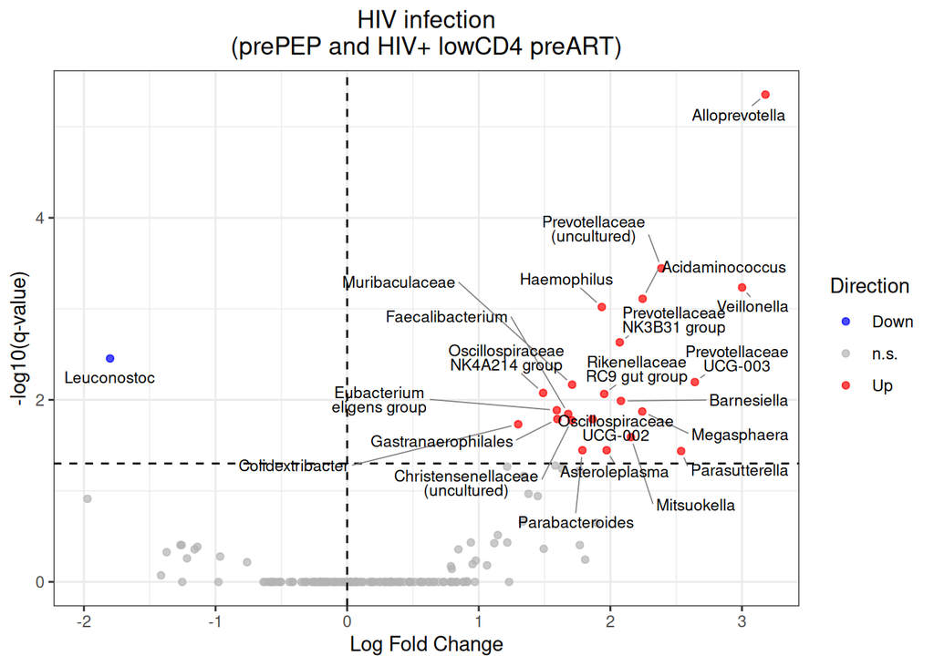

```r
f3A <- ggplot(volc_HIV, aes(x = logFC, y = neglog10q)) +
    geom_point(aes(color = direction), alpha = 0.7) +

    geom_hline(yintercept = -log10(0.05), linetype = "dashed") +
    geom_vline(xintercept = 0, linetype = "dashed") +

    geom_text_repel(
        data = subset(volc_HIV, qval < 0.05),
        aes(label = taxon_label),
        size = 3,
        max.overlaps = Inf,
        force = 25,
        force_pull = 0.5,
        segment.color = "grey50",
        segment.size = 0.3,
        min.segment.length = 0.1,
        box.padding = 0.4,
        point.padding = 0.2,
        lineheight = 0.75
    ) +

    scale_color_manual(values = c("Down" = "blue", "n.s." = "grey70", "Up" = "red")) +

    theme_bw() +
    labs(
        x = "Log Fold Change",
        y = "-log10(q-value)",
        color = "Direction",
        title = "HIV infection\n(prePEP and HIV+ lowCD4 preART)"
    ) +
    theme(plot.title = element_text(hjust = 0.5))
f3A
```

## Short-term PEP exposure (Figure 4C, Supplementary Table 3)

```r
tse_ART <- tse[, colData(tse)$group %in% c("prePEP_HIV-", "postPEP_HIV-")]
colData(tse_ART)$group = factor(colData(tse_ART)$group, levels = c("prePEP_HIV-", "postPEP_HIV-"))
# Run ANCOMBC2
results_ART <- ancombc2(tse_ART, fix_formula = "group")
res_prim_ART <- results_ART$res
# write_tsv(res_prim_ART, "tables/taxa_pep_exposure.tsv")
```

### Volcano plot

```r
res_prim_ART$taxon_label <- clean_taxon_name(res_prim_ART$taxon)

res_prim_ART |>
  filter(`q_grouppostPEP_HIV-` < 0.05) |>
  mutate(taxon = gsub("\\n", " ", taxon_label),
            log_fold_change = `lfc_grouppostPEP_HIV-`,
            q_value = `q_grouppostPEP_HIV-`, .keep = "none") |>
  arrange(q_value)
```

| taxon | log_fold_change | q_value |
| --- | --- | --- |
| Lachnospira | -2.207945 | 0.007007035 |
| Succinivibrio | -2.125187 | 0.012726694 |
| Haemophilus | 1.575908 | 0.026625077 |

```r
volc_ART <- res_prim_ART |>
  mutate(
    logFC = `lfc_grouppostPEP_HIV-`,
    qval  = `q_grouppostPEP_HIV-`,
    neglog10q = -log10(qval),
    direction = case_when(
      qval < 0.05 & logFC > 0 ~ "Up",
      qval < 0.05 & logFC < 0 ~ "Down",
      TRUE ~ "n.s."
    )
  )
```

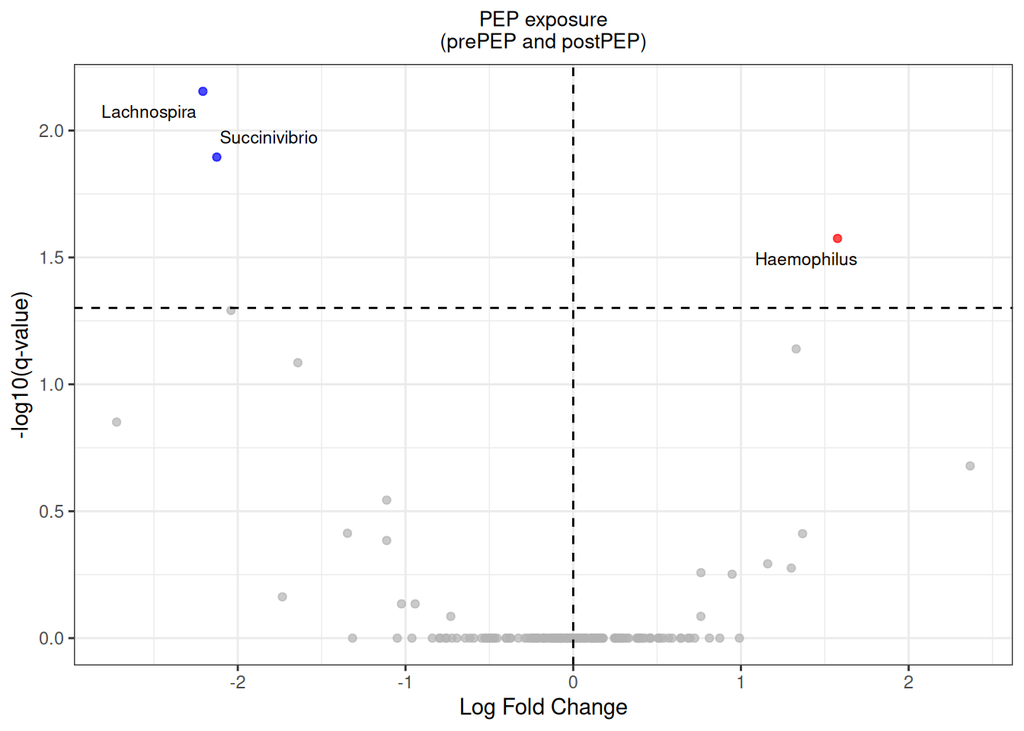

```r
f3C <- ggplot(volc_ART, aes(x = logFC, y = neglog10q)) +
    geom_point(aes(color = direction), alpha = 0.7) +

    geom_hline(yintercept = -log10(0.05), linetype = "dashed") +
    geom_vline(xintercept = 0, linetype = "dashed") +

    geom_text_repel(
        data = subset(volc_ART, qval < 0.05),
        aes(label = taxon_label),
        size = 3,
        max.overlaps = Inf,
        force = 2,
        force_pull = 0.5,
        segment.color = "grey50",
        segment.size = 0.3,
        box.padding = 0.4,
        point.padding = 0.2
    ) +

    scale_color_manual(values = c("Down" = "blue", "n.s." = "grey70", "Up" = "red")) +

    theme_bw() +
    labs(
        x = "Log Fold Change",
        y = "-log10(q-value)",
        color = "Direction",
        title = "PEP exposure\n(prePEP and postPEP)"
    ) +
    theme(legend.position = "none",
          plot.title = element_text(size = 10, hjust = 0.5))
f3C
```

## Immune status (Figure 4B, Supplementary Table 2)

```r
tse_immuno <- tse[, colData(tse)$group %in% c("shortART_HIV+", "longART_HIV+")]
colData(tse_immuno)$group = factor(colData(tse_immuno)$group, levels = c("shortART_HIV+", "longART_HIV+"))
# Run ANCOMBC2
results_immuno <- ancombc2(tse_immuno, fix_formula = "group")
res_prim_immuno <- results_immuno$res
# write_tsv(res_prim_immuno, "tables/taxa_immune_status.tsv")
```

### Volcano plot

```r
res_prim_immuno$taxon_label <- clean_taxon_name(res_prim_immuno$taxon)

res_prim_immuno |>
  filter(`q_grouplongART_HIV+` < 0.05) |>
  mutate(taxon = gsub("\\n", " ", taxon_label),
            log_fold_change = `lfc_grouplongART_HIV+`,
            q_value = `q_grouplongART_HIV+`, .keep = "none") |>
  arrange(q_value)
```

| taxon | log_fold_change | q_value |
| --- | --- | --- |
| Mailhella | 2.361204 | 0.003077525 |
| Oscillospiraceae (uncultured) | 1.856961 | 0.008464462 |
| Barnesiella | 3.588283 | 0.022122864 |

```r
volc_immuno <- res_prim_immuno |>
  mutate(
    logFC = `lfc_grouplongART_HIV+`,
    qval  = `q_grouplongART_HIV+`,
    neglog10q = -log10(qval),
    direction = case_when(
      qval < 0.05 & logFC > 0 ~ "Up",
      qval < 0.05 & logFC < 0 ~ "Down",
      TRUE ~ "n.s."
    )
  )
```

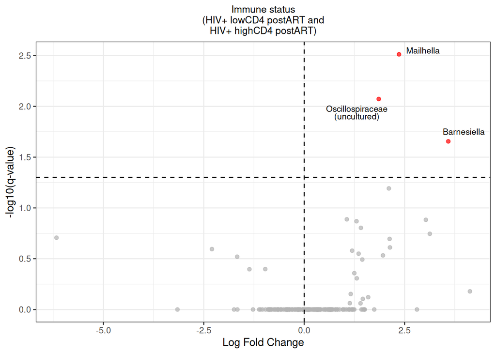

```r
f3B <- ggplot(volc_immuno, aes(x = logFC, y = neglog10q)) +
    geom_point(aes(color = direction), alpha = 0.7) +

    geom_hline(yintercept = -log10(0.05), linetype = "dashed") +
    geom_vline(xintercept = 0, linetype = "dashed") +

    geom_text_repel(
        data = subset(volc_immuno, qval < 0.05),
        aes(label = taxon_label),
        size = 3,
        max.overlaps = Inf,
        force = 2,
        force_pull = 0.5,
        segment.color = "grey50",
        segment.size = 0.3,
        box.padding = 0.4,
        point.padding = 0.2,
        lineheight = 0.75
    ) +

    scale_color_manual(values = c("Down" = "blue", "n.s." = "grey70", "Up" = "red")) +

    theme_bw() +
    labs(
        x = "Log Fold Change",
        y = "-log10(q-value)",
        color = "Direction",
        title = "Immune status\n(HIV+ lowCD4 postART and\nHIV+ highCD4 postART)"
    ) +
    theme(legend.position = "none",
          plot.title = element_text(size = 10, hjust = 0.5))
f3B
```

## Final figure (differential abundance analyis)

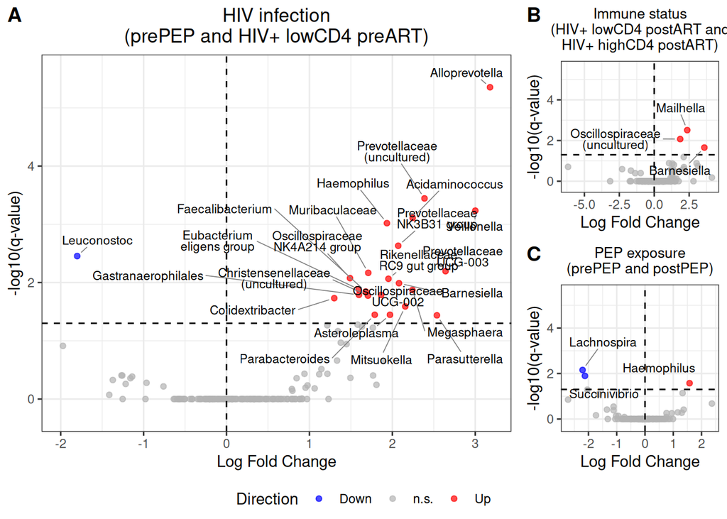

```r
# svg("figures/differential_taxa.svg", width = 10.5, height = 7.5)

y_lim <- ggplot_build(f3A)$layout$panel_params[[1]]$y.range
f3Ay <- f3A + coord_cartesian(ylim = y_lim)
f3By <- f3B + coord_cartesian(ylim = y_lim)
f3Cy <- f3C + coord_cartesian(ylim = y_lim)

right <- ggpubr::ggarrange(
    f3By, f3Cy,
    ncol = 1,
    labels = c("B", "C")
)

ggpubr::ggarrange(
    f3Ay, right,
    ncol = 2,
    widths = c(2.5, 1),   # A wider than B/C column
    labels = c("A", ""),
    common.legend = TRUE,
    legend = "bottom"
)
```

```r
# dev.off()
```

# Predicted functional profiles

PICRUSt2-predicted absolute abundances of KEGG orthologs (KO) and Enzyme Classification (EC) terms were analyzed with ANCOM-BC2. Complete results remain available through optional TSV exports. To keep the HTML concise, rendered tables include significant terms with an absolute log fold change of at least 2 (**Figure 5A–F, Supplementary Tables 4–9**).

## KEGG orthologs (KO terms)

Build a TreeSummarizedExperiment:

```r
# Read abundance table
KO_table <- read_tsv("data/picrust2_ko_abundance.tsv") |>
    dplyr::rename(KO = `function`)
# Create microbial count table
KO_mat <- as.matrix(KO_table[, c(-1, -2)])
rownames(KO_mat) <- KO_table$KO
KO_assays <- SimpleList(counts = KO_mat)
```

```r
# Create metadata table
smd <- align_metadata(KO_mat, metadata)
```

Create TSE:

```r
KO_tse <- TreeSummarizedExperiment(assays = KO_assays,
                                   colData = smd,
                                   rowData = NULL)
```

### HIV status (Figure 5A, Supplementary Table 4)

Create tse by filtering previous tse:

```r
# QUESTION: Differences between HIV infection status
KO_tse_HIV <- KO_tse[, colData(KO_tse)$group %in% c("prePEP_HIV-", "naive_HIV+")]
colData(KO_tse_HIV)$group = factor(colData(KO_tse_HIV)$group, levels = c("prePEP_HIV-", "naive_HIV+"))
# Remove zero variance KOs
drop_kos <- c("K00187", "K00188", "K01563", "K02756", "K09744",
              "K10353", "K11176", "K11540", "K14439", "K13714",
              "K18295", "K18481")
KO_tse_HIV <- KO_tse_HIV[!rownames(KO_tse_HIV) %in% drop_kos, ]
# Run ANCOMBC2
KO_results_HIV <- ancombc2(KO_tse_HIV, fix_formula = "group")
KO_res_prim_HIV <- KO_results_HIV$res
KO_res_prim_HIV <- KO_res_prim_HIV |>
    dplyr::left_join(KO_table[, c("KO", "description")], by = c("taxon" = "KO")) |>
    relocate(taxon, description) |>
    rename(KO = taxon)
# write_tsv(KO_res_prim_HIV, "tables/ko_hiv_status.tsv")
```

The concise table below shows the significant KO terms with $|LFC| \geq 2$. The optional TSV export retains the complete ANCOM-BC2 result, including terms with q-values above 0.05.

```r
KO_res_prim_HIV |>
  filter(`q_groupnaive_HIV+` < 0.05, abs(`lfc_groupnaive_HIV+`) >= 2) |>
  mutate(KO, description, log_fold_change = `lfc_groupnaive_HIV+`,
            q_value = `q_groupnaive_HIV+`, .keep = "none") |>
  arrange(q_value)
```

| KO | description | log_fold_change | q_value |
| --- | --- | --- | --- |
| K07277 | SAM50, TOB55, bamA; outer membrane protein insertion porin family | 2.033649 | 4.448121e-05 |
| K03642 | rlpA; rare lipoprotein A | 2.388325 | 5.497729e-05 |
| K06861 | lptB; lipopolysaccharide export system ATP-binding protein [EC:3.6.3.-] | 2.069609 | 5.563814e-05 |
| K02523 | ispB; octaprenyl-diphosphate synthase [EC:2.5.1.90] | 2.026935 | 5.832800e-05 |
| K11720 | lptG; lipopolysaccharide export system permease protein | 2.058754 | 5.863486e-05 |
| K02536 | lpxD; UDP-3-O-[3-hydroxymyristoyl] glucosamine N-acyltransferase [EC:2.3.1.191] | 2.079831 | 6.424679e-05 |
| K02527 | kdtA, waaA; 3-deoxy-D-manno-octulosonic-acid transferase [EC:2.4.99.12 2.4.99.13 2.4.99.14 2.4.99.15] | 2.063298 | 6.555753e-05 |
| K01627 | kdsA; 2-dehydro-3-deoxyphosphooctonate aldolase (KDO 8-P synthase) [EC:2.5.1.55] | 2.049177 | 6.556790e-05 |
| K00748 | lpxB; lipid-A-disaccharide synthase [EC:2.4.1.182] | 2.071793 | 6.608415e-05 |
| K00912 | lpxK; tetraacyldisaccharide 4'-kinase [EC:2.7.1.130] | 2.052927 | 6.621906e-05 |

[output cut: 87 more lines]

#### Volcano plot

```r
KO_res_prim_HIV$plot_label <- mapply(make_ko_label, KO_res_prim_HIV$KO, KO_res_prim_HIV$description)
```

```r
volc_KO_HIV <- KO_res_prim_HIV |>
  mutate(
    logFC = `lfc_groupnaive_HIV+`,
    qval  = `q_groupnaive_HIV+`,
    neglog10q = -log10(qval),
    direction = case_when(
      qval < 0.05 & logFC > 0 ~ "Up",
      qval < 0.05 & logFC < 0 ~ "Down",
      TRUE ~ "n.s."
    )
  )
# Filter because there are too many
# Get top 10 and bottom 10 indices
sig_idx <- which(volc_KO_HIV$qval < 0.05 & !is.na(volc_KO_HIV$plot_label))

sig_logFC <- volc_KO_HIV$logFC[sig_idx]

top_sig_idx <- sig_idx[order(sig_logFC, decreasing = TRUE)[1:min(5, length(sig_idx))]]
bottom_sig_idx <- sig_idx[order(sig_logFC, decreasing = FALSE)[1:min(5, length(sig_idx))]]

keep_idx <- unique(c(top_sig_idx, bottom_sig_idx))

volc_KO_HIV$label_to_plot <- ifelse(seq_len(nrow(volc_KO_HIV)) %in% keep_idx,
                                volc_KO_HIV$plot_label,
                                NA_character_)
```

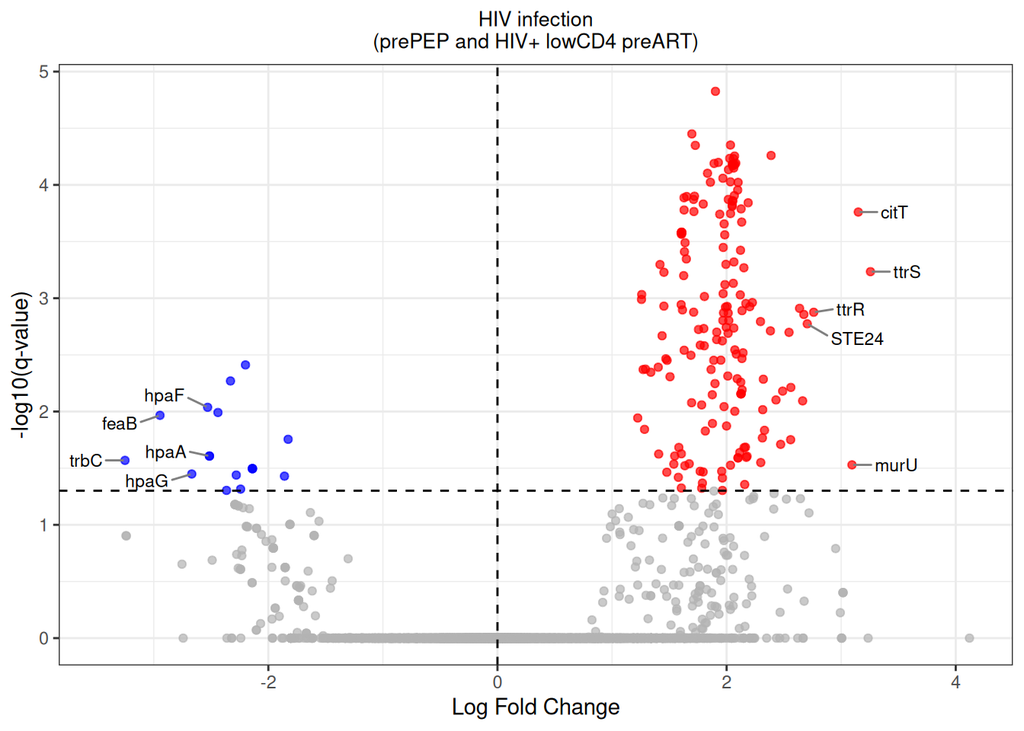

```r
f4A <- ggplot(volc_KO_HIV, aes(x = logFC, y = neglog10q)) +
    geom_point(aes(color = direction), alpha = 0.7) +

    geom_hline(yintercept = -log10(0.05), linetype = "dashed") +
    geom_vline(xintercept = 0, linetype = "dashed") +

# Left side labels
geom_text_repel(
  data = subset(volc_KO_HIV, !is.na(label_to_plot) & logFC < 0),
  aes(label = label_to_plot),
  size = 3,
  nudge_x = -0.2,
  hjust = 1,
  direction = "y",
  force = 3,
  force_pull = 0.2,
  max.overlaps = Inf,
  segment.color = "grey50",
  min.segment.length = 0.1
) +

# Right side labels
geom_text_repel(
  data = subset(volc_KO_HIV, !is.na(label_to_plot) & logFC > 0),
  aes(label = label_to_plot),
  size = 3,
  nudge_x = 0.2,
  hjust = 0,
  direction = "y",
  force = 3,
  force_pull = 0.2,
  max.overlaps = Inf,
  segment.color = "grey50",
  min.segment.length = 0.1
) +

    scale_color_manual(values = c("Down" = "blue", "n.s." = "grey70", "Up" = "red")) +

    theme_bw() +
    labs(
        x = "Log Fold Change",
        y = "-log10(q-value)",
        color = "Direction",
        title = "HIV infection\n(prePEP and HIV+ lowCD4 preART)"
    ) +
    theme(legend.position = "none",
          plot.title = element_text(size = 10, hjust = 0.5))
f4A
```

### Short-term PEP exposure (Figure 5C, Supplementary Table 8)

```r
tse_KO_ART <- KO_tse[, colData(KO_tse)$group %in% c("prePEP_HIV-", "postPEP_HIV-")]
colData(tse_KO_ART)$group = factor(colData(tse_KO_ART)$group, levels = c("prePEP_HIV-", "postPEP_HIV-"))
# Run ANCOMBC2
results_KO_ART <- ancombc2(tse_KO_ART, fix_formula = "group")
KO_res_prim_ART <- results_KO_ART$res |>
    dplyr::left_join(KO_table[, c("KO", "description")], by = c("taxon" = "KO")) |>
    dplyr::relocate(taxon, description) |>
    dplyr::rename(KO = taxon)
# write_tsv(KO_res_prim_ART, "tables/ko_pep_exposure.tsv")
```

```r
KO_res_prim_ART |>
  filter(`q_grouppostPEP_HIV-` < 0.05, abs(`lfc_grouppostPEP_HIV-`) >= 2) |>
  mutate(KO, description, log_fold_change = `lfc_grouppostPEP_HIV-`,
            q_value = `q_grouppostPEP_HIV-`, .keep = "none") |>
  arrange(q_value)
```

| KO | description | log_fold_change | q_value |
| --- | --- | --- | --- |
| K11910 | vasJ; type VI secretion system protein VasJ | 2.375268 | 0.003335423 |
| K02840 | waaB, rfaB; UDP-D-galactose:(glucosyl)LPS alpha-1,6-D-galactosyltransferase [EC:2.4.1.-] | 2.700135 | 0.005359361 |
| K11905 | K11905; type VI secretion system protein | 2.248073 | 0.006608468 |
| K11892 | impK, ompA, vasF, dotU; type VI secretion system protein ImpK | 2.073971 | 0.006928525 |
| K01668 | E4.1.99.2; tyrosine phenol-lyase [EC:4.1.99.2] | 2.158270 | 0.007714386 |
| K11906 | vasD, lip; type VI secretion system protein VasD | 2.063093 | 0.008113241 |
| K13010 | per, rfbE; perosamine synthetase [EC:2.6.1.102] | -2.432990 | 0.047820552 |

#### Volcano plot

```r
KO_res_prim_ART$plot_label <- mapply(make_ko_label, KO_res_prim_ART$KO, KO_res_prim_ART$description)
```

```r
volc_KO_ART <- KO_res_prim_ART |>
  mutate(
    logFC = `lfc_grouppostPEP_HIV-`,
    qval  = `q_grouppostPEP_HIV-`,
    neglog10q = -log10(qval),
    direction = case_when(
      qval < 0.05 & logFC > 0 ~ "Up",
      qval < 0.05 & logFC < 0 ~ "Down",
      TRUE ~ "n.s."
    )
  )
```

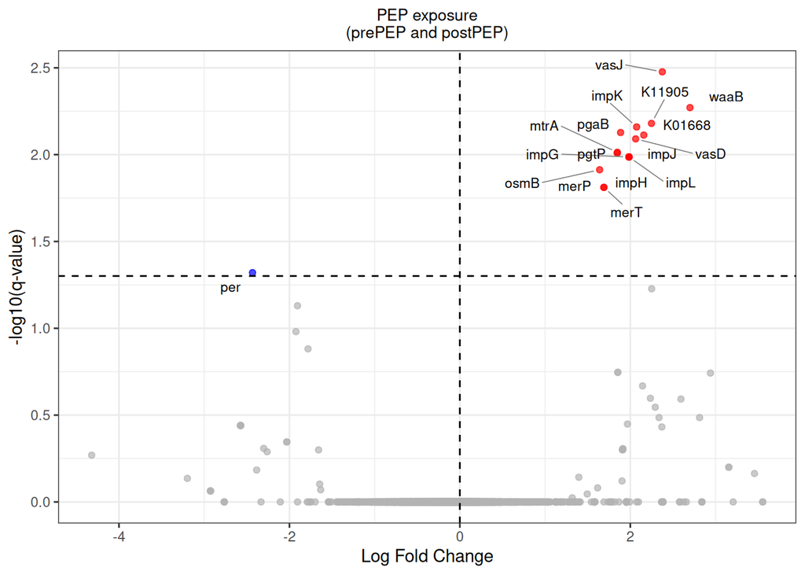

```r
f4C <- ggplot(volc_KO_ART, aes(x = logFC, y = neglog10q)) +
    geom_point(aes(color = direction), alpha = 0.7) +

    geom_hline(yintercept = -log10(0.05), linetype = "dashed") +
    geom_vline(xintercept = 0, linetype = "dashed") +

    geom_text_repel(
        data = subset(volc_KO_ART, qval < 0.05),
        aes(label = plot_label),
        size = 3,
        max.overlaps = Inf,
        force = 2,
        force_pull = 0.5,
        segment.color = "grey50",
        segment.size = 0.3,
        box.padding = 0.4,
        point.padding = 0.2,
        lineheight = 0.75
    ) +

    scale_color_manual(values = c("Down" = "blue", "n.s." = "grey70", "Up" = "red")) +

    theme_bw() +
    labs(
        x = "Log Fold Change",
        y = "-log10(q-value)",
        color = "Direction",
        title = "PEP exposure\n(prePEP and postPEP)"
    ) +
    theme(legend.position = "none",
          plot.title = element_text(size = 10, hjust = 0.5))
f4C
```

### Immune status (Figure 5B, Supplementary Table 6)

```r
tse_KO_immuno <- KO_tse[, colData(KO_tse)$group %in% c("shortART_HIV+", "longART_HIV+")]
colData(tse_KO_immuno)$group = factor(colData(tse_KO_immuno)$group, levels = c("shortART_HIV+", "longART_HIV+"))
# Run ANCOMBC2
results_KO_immuno <- ancombc2(tse_KO_immuno, fix_formula = "group")
KO_res_prim_immuno <- results_KO_immuno$res |>
    dplyr::left_join(KO_table[, c("KO", "description")], by = c("taxon" = "KO")) |>
    dplyr::relocate(taxon, description) |>
    dplyr::rename(KO = taxon)
# write_tsv(KO_res_prim_immuno, "tables/ko_immune_status.tsv")
```

```r
KO_res_prim_immuno |>
  filter(`q_grouplongART_HIV+` < 0.05, abs(`lfc_grouplongART_HIV+`) >= 2) |>
  mutate(KO, description, log_fold_change = `lfc_grouplongART_HIV+`,
            q_value = `q_grouplongART_HIV+`, .keep = "none") |>
  arrange(q_value)
```

| KO | description | log_fold_change | q_value |
| --- | --- | --- | --- |
| K17248 | pglJ; N-acetylgalactosamine-N,N'-diacetylbacillosaminyl-diphospho-undecaprenol 4-alpha-N-acetylgalactosaminyltransferase [EC:2.4.1.291] | 3.079198 | 0.0008686545 |
| K13935 | mdcH; malonate decarboxylase epsilon subunit [EC:2.3.1.39] | -4.728290 | 0.0018635512 |
| K07100 | K07100; putative phosphoribosyl transferase | 3.060382 | 0.0023181202 |
| K18284 | K18284; adenosylhomocysteine/aminodeoxyfutalosine nucleosidase [EC:3.2.2.9 3.2.2.30] | 2.944263 | 0.0037980012 |
| K05927 | hydA; quinone-reactive Ni/Fe-hydrogenase small subunit [EC:1.12.5.1] | 2.413418 | 0.0102952529 |
| K01959 | pycA; pyruvate carboxylase subunit A [EC:6.4.1.1] | 2.189625 | 0.0336702240 |
| K05922 | hydB; quinone-reactive Ni/Fe-hydrogenase large subunit [EC:1.12.5.1] | 2.282454 | 0.0385100840 |
| K06882 | K06882; uncharacterized protein | 2.282454 | 0.0385100840 |
| K08077 | NUDT14; UDP-sugar diphosphatase [EC:3.6.1.45] | 2.282454 | 0.0385100840 |
| K09804 | K09804; uncharacterized protein | 2.282454 | 0.0385100840 |

[output cut: 2 more lines]

#### Volcano plot

```r
KO_res_prim_immuno$plot_label <- mapply(make_ko_label, KO_res_prim_immuno$KO, KO_res_prim_immuno$description)
```

```r
volc_KO_immuno <- KO_res_prim_immuno |>
  mutate(
    logFC = `lfc_grouplongART_HIV+`,
    qval  = `q_grouplongART_HIV+`,
    neglog10q = -log10(qval),
    direction = case_when(
      qval < 0.05 & logFC > 0 ~ "Up",
      qval < 0.05 & logFC < 0 ~ "Down",
      TRUE ~ "n.s."
    )
  )
```

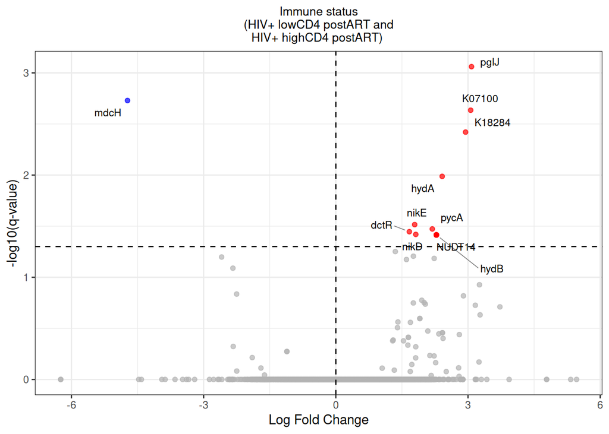

```r
f4B <- ggplot(volc_KO_immuno, aes(x = logFC, y = neglog10q)) +
    geom_point(aes(color = direction), alpha = 0.7) +

    geom_hline(yintercept = -log10(0.05), linetype = "dashed") +
    geom_vline(xintercept = 0, linetype = "dashed") +

    geom_text_repel(
        data = subset(volc_KO_immuno, qval < 0.05),
        aes(label = plot_label),
        size = 3,
        max.overlaps = Inf,
        force = 2,
        force_pull = 0.5,
        segment.color = "grey50",
        segment.size = 0.3,
        box.padding = 0.4,
        point.padding = 0.2,
        lineheight = 0.75
    ) +

    scale_color_manual(values = c("Down" = "blue", "n.s." = "grey70", "Up" = "red")) +

    theme_bw() +
    labs(
        x = "Log Fold Change",
        y = "-log10(q-value)",
        color = "Direction",
        title = "Immune status\n(HIV+ lowCD4 postART and\nHIV+ highCD4 postART) "
    ) +
    theme(legend.position = "none",
          plot.title = element_text(size = 10, hjust = 0.5))
f4B
```

## Enzymes (EC numbers)

Build a TreeSummarizedExperiment:

```r
# Read abundance table
EC_table <- read_tsv("data/picrust2_ec_abundance.tsv") |>
    dplyr::rename(EC = `function`)
# Create microbial count table
EC_mat <- as.matrix(EC_table[, c(-1, -2)])
rownames(EC_mat) <- EC_table$EC
EC_assays <- SimpleList(counts = EC_mat)
```

```r
# Create metadata table
smd <- align_metadata(EC_mat, metadata)
```

Create TSE:

```r
EC_tse <- TreeSummarizedExperiment(assays = EC_assays,
                                   colData = smd,
                                   rowData = NULL)
```

### HIV status (Figure 5D, Supplementary Table 5)

Create tse by filtering previous tse:

```r
# QUESTION: Differences between HIV infection status
EC_tse_HIV <- EC_tse[, colData(EC_tse)$group %in% c("prePEP_HIV-", "naive_HIV+")]
colData(EC_tse_HIV)$group = factor(colData(EC_tse_HIV)$group, levels = c("prePEP_HIV-", "naive_HIV+"))
# Run ANCOMBC2
EC_results_HIV <- ancombc2(EC_tse_HIV, fix_formula = "group")
EC_res_prim_HIV <- EC_results_HIV$res
EC_res_prim_HIV <- EC_res_prim_HIV |>
    dplyr::left_join(EC_table[, c("EC", "description")], by = c("taxon" = "EC")) |>
    dplyr::relocate(taxon, description) |>
    dplyr::rename(EC = taxon)
# write_tsv(EC_res_prim_HIV, "tables/ec_hiv_status.tsv")
```

The concise table below shows the significant EC terms with $|LFC| \geq 2$. The optional TSV export retains the complete ANCOM-BC2 result, including terms with q-values above 0.05.

```r
EC_res_prim_HIV |>
  filter(`q_groupnaive_HIV+` < 0.05, abs(`lfc_groupnaive_HIV+`) >= 2) |>
  mutate(EC, description, log_fold_change = `lfc_groupnaive_HIV+`,
            q_value = `q_groupnaive_HIV+`, .keep = "none") |>
  arrange(q_value)
```

| EC | description | log_fold_change | q_value |
| --- | --- | --- | --- |
| EC:2.3.1.191 | UDP-3-O-(3-hydroxymyristoyl)glucosamine N-acyltransferase | 2.024642 | 6.282776e-06 |
| EC:2.4.99.12 | Lipid IV(A) 3-deoxy-D-manno-octulosonic acid transferase | 2.008109 | 6.363274e-06 |
| EC:2.4.99.13 | (Kdo)-lipid IV(A) 3-deoxy-D-manno-octulosonic acid transferase | 2.008109 | 6.363274e-06 |
| EC:2.4.99.14 | (Kdo)(2)-lipid IV(A) (2-8) 3-deoxy-D-manno-octulosonic acid transferase | 2.008109 | 6.363274e-06 |
| EC:2.4.99.15 | (Kdo)(3)-lipid IV(A) (2-4) 3-deoxy-D-manno-octulosonic acid transferase | 2.008109 | 6.363274e-06 |
| EC:2.4.1.182 | Lipid-A-disaccharide synthase | 2.016604 | 6.471360e-06 |
| EC:3.5.1.108 | UDP-3-O-acyl-N-acetylglucosamine deacetylase | 2.027420 | 7.331520e-06 |
| EC:1.1.1.40 | Malate dehydrogenase (oxaloacetate-decarboxylating) (NADP(+)) | 2.011862 | 1.450453e-05 |
| EC:2.3.1.129 | Acyl-[acyl-carrier-protein]--UDP-N-acetylglucosamine O-acyltransferase | 2.071352 | 1.664953e-05 |
| EC:2.7.1.25 | Adenylyl-sulfate kinase | 2.085788 | 4.952770e-05 |

[output cut: 30 more lines]

```r
volc_EC_HIV <- EC_res_prim_HIV |>
  mutate(
    logFC = `lfc_groupnaive_HIV+`,
    qval  = `q_groupnaive_HIV+`,
    neglog10q = -log10(qval),
    direction = case_when(
      qval < 0.05 & logFC > 0 ~ "Up",
      qval < 0.05 & logFC < 0 ~ "Down",
      TRUE ~ "n.s."
    )
  )

# Filter because there are too many
# Get top 10 and bottom 10 indices
sig_idx <- which(volc_EC_HIV$qval < 0.05)

sig_logFC <- volc_EC_HIV$logFC[sig_idx]

top_sig_idx <- sig_idx[order(sig_logFC, decreasing = TRUE)[1:min(5, length(sig_idx))]]
bottom_sig_idx <- sig_idx[order(sig_logFC, decreasing = FALSE)[1:min(5, length(sig_idx))]]

keep_idx <- unique(c(top_sig_idx, bottom_sig_idx))

volc_EC_HIV$label_to_plot <- ifelse(seq_len(nrow(volc_EC_HIV)) %in% keep_idx,
                                volc_EC_HIV$EC,
                                NA_character_)
```

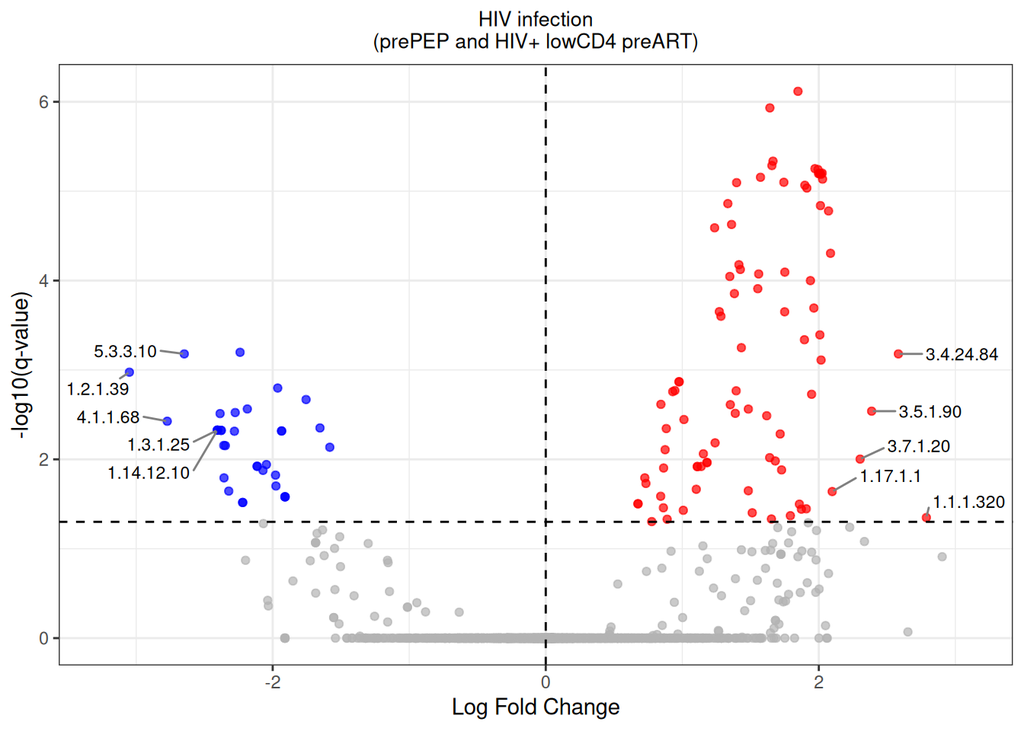

```r
f4D <- ggplot(volc_EC_HIV, aes(x = logFC, y = neglog10q)) +
    geom_point(aes(color = direction), alpha = 0.7) +

    geom_hline(yintercept = -log10(0.05), linetype = "dashed") +
    geom_vline(xintercept = 0, linetype = "dashed") +
    # Left side labels
geom_text_repel(
  data = subset(volc_EC_HIV, logFC < 0),
  aes(label = gsub("EC:", "", label_to_plot)),
  size = 3,
  nudge_x = -0.2,
  hjust = 1,
  direction = "y",
  force = 3,
  force_pull = 0.2,
  max.overlaps = Inf,
  segment.color = "grey50",
  min.segment.length = 0.1
) +

# Right side labels
geom_text_repel(
  data = subset(volc_EC_HIV, logFC > 0),
  aes(label = gsub("EC:", "", label_to_plot)),
  size = 3,
  nudge_x = 0.2,
  hjust = 0,
  direction = "y",
  force = 3,
  force_pull = 0.2,
  max.overlaps = Inf,
  segment.color = "grey50",
  min.segment.length = 0.1
) +
    scale_color_manual(values = c("Down" = "blue", "n.s." = "grey70", "Up" = "red")) +

    theme_bw() +
    labs(
        x = "Log Fold Change",
        y = "-log10(q-value)",
        color = "Direction",
        title = "HIV infection\n(prePEP and HIV+ lowCD4 preART)"
    ) +
    theme(legend.position = "none",
          plot.title = element_text(size = 10, hjust = 0.5))
f4D
```

### Short-term PEP exposure (Figure 5F, Supplementary Table 9)

```r
tse_EC_ART <- EC_tse[, colData(EC_tse)$group %in% c("prePEP_HIV-", "postPEP_HIV-")]
colData(tse_EC_ART)$group = factor(colData(tse_EC_ART)$group, levels = c("prePEP_HIV-", "postPEP_HIV-"))
# Run ANCOMBC2
results_EC_ART <- ancombc2(tse_EC_ART, fix_formula = "group")
EC_res_prim_ART <- results_EC_ART$res |>
    dplyr::left_join(EC_table[, c("EC", "description")], by = c("taxon" = "EC")) |>
    dplyr::relocate(taxon, description) |>
    dplyr::rename(EC = taxon)
# write_tsv(EC_res_prim_ART, "tables/ec_pep_exposure.tsv")
```

```r
EC_res_prim_ART |>
  filter(`q_grouppostPEP_HIV-` < 0.05, abs(`lfc_grouppostPEP_HIV-`) >= 2) |>
  mutate(EC, description, log_fold_change = `lfc_grouppostPEP_HIV-`,
            q_value = `q_grouppostPEP_HIV-`, .keep = "none") |>
  arrange(q_value)
```

| EC | description | log_fold_change | q_value |
| --- | --- | --- | --- |
| EC:4.1.99.2 | Tyrosine phenol-lyase | 2.338710 | 0.000347750 |
| EC:2.6.1.102 | GDP-perosamine synthase | -2.291752 | 0.009232485 |
| EC:4.3.1.29 | D-glucosaminate-6-phosphate ammonia lyase | 2.129839 | 0.034536873 |
| EC:1.1.1.264 | L-idonate 5-dehydrogenase (NAD(P)(+)) | 2.504019 | 0.043824554 |

```r
volc_EC_ART <- EC_res_prim_ART |>
  mutate(
    logFC = `lfc_grouppostPEP_HIV-`,
    qval  = `q_grouppostPEP_HIV-`,
    neglog10q = -log10(qval),
    direction = case_when(
      qval < 0.05 & logFC > 0 ~ "Up",
      qval < 0.05 & logFC < 0 ~ "Down",
      TRUE ~ "n.s."
    )
  )
```

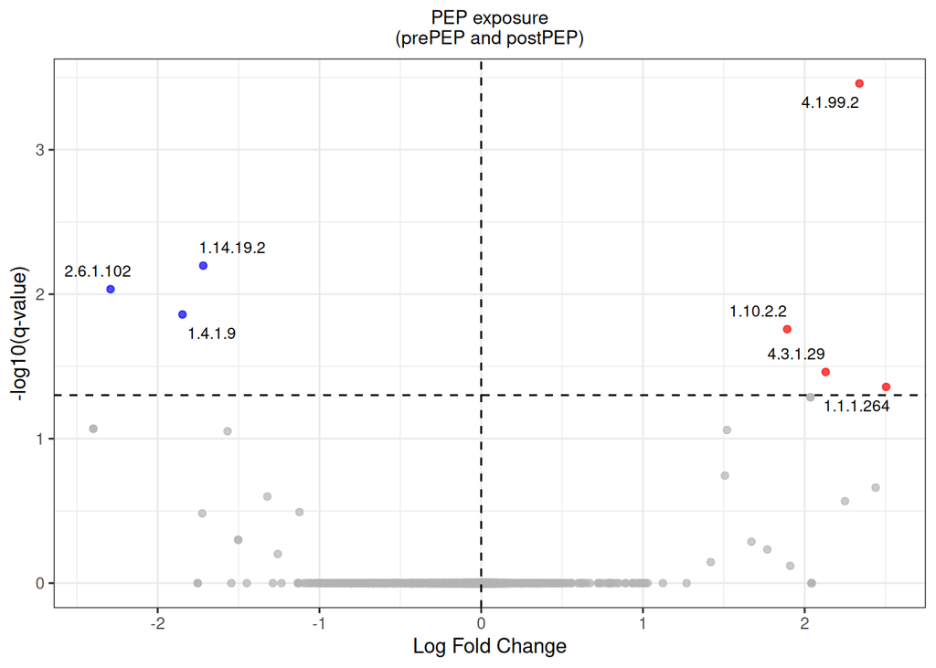

```r
f4F <- ggplot(volc_EC_ART, aes(x = logFC, y = neglog10q)) +
    geom_point(aes(color = direction), alpha = 0.7) +

    geom_hline(yintercept = -log10(0.05), linetype = "dashed") +
    geom_vline(xintercept = 0, linetype = "dashed") +

    geom_text_repel(
        data = subset(volc_EC_ART, qval < 0.05),
        aes(label = gsub("EC:", "", EC)),
        size = 3,
        max.overlaps = Inf,
        force = 2,
        force_pull = 0.5,
        segment.color = "grey50",
        segment.size = 0.3,
        box.padding = 0.4,
        point.padding = 0.2,
        lineheight = 0.75
    ) +

    scale_color_manual(values = c("Down" = "blue", "n.s." = "grey70", "Up" = "red")) +

    theme_bw() +
    labs(
        x = "Log Fold Change",
        y = "-log10(q-value)",
        color = "Direction",
        title = "PEP exposure\n(prePEP and postPEP)"
    ) +
    theme(legend.position = "none",
          plot.title = element_text(size = 10, hjust = 0.5))
f4F
```

### Immune status (Figure 5E, Supplementary Table 7)

```r
tse_EC_immuno <- EC_tse[, colData(EC_tse)$group %in% c("shortART_HIV+", "longART_HIV+")]
colData(tse_EC_immuno)$group = factor(colData(tse_EC_immuno)$group, levels = c("shortART_HIV+", "longART_HIV+"))
# Run ANCOMBC2
results_EC_immuno <- ancombc2(tse_EC_immuno, fix_formula = "group")
EC_res_prim_immuno <- results_EC_immuno$res |>
    dplyr::left_join(EC_table[, c("EC", "description")], by = c("taxon" = "EC")) |>
    dplyr::relocate(taxon, description) |>
    dplyr::rename(EC = taxon)
# write_tsv(EC_res_prim_immuno, "tables/ec_immune_status.tsv")
```

```r
EC_res_prim_immuno |>
  filter(`q_grouplongART_HIV+` < 0.05, abs(`lfc_grouplongART_HIV+`) >= 2) |>
  mutate(EC, description, log_fold_change = `lfc_grouplongART_HIV+`,
            q_value = `q_grouplongART_HIV+`, .keep = "none") |>
  arrange(q_value)
```

| EC | description | log_fold_change | q_value |
| --- | --- | --- | --- |
| EC:2.4.1.291 | 4-alpha-N-acetylgalactosaminyltransferase | 3.033370 | 0.0001790315 |
| EC:3.2.2.30 | Aminodeoxyfutalosine nucleosidase | 2.809624 | 0.0013642408 |
| EC:1.12.5.1 | Hydrogen:quinone oxidoreductase | 2.237073 | 0.0062852800 |
| EC:2.5.1.44 | Homospermidine synthase | -2.674681 | 0.0120876840 |

```r
volc_EC_immuno <- EC_res_prim_immuno |>
  mutate(
    logFC = `lfc_grouplongART_HIV+`,
    qval  = `q_grouplongART_HIV+`,
    neglog10q = -log10(qval),
    direction = case_when(
      qval < 0.05 & logFC > 0 ~ "Up",
      qval < 0.05 & logFC < 0 ~ "Down",
      TRUE ~ "n.s."
    )
  )
```

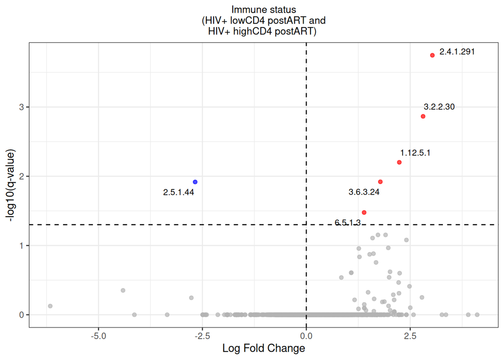

```r
f4E <- ggplot(volc_EC_immuno, aes(x = logFC, y = neglog10q)) +
    geom_point(aes(color = direction), alpha = 0.7) +

    geom_hline(yintercept = -log10(0.05), linetype = "dashed") +
    geom_vline(xintercept = 0, linetype = "dashed") +

    geom_text_repel(
        data = subset(volc_EC_immuno, qval < 0.05),
        aes(label = gsub("EC:", "", EC)),
        size = 3,
        max.overlaps = Inf,
        force = 2,
        force_pull = 0.5,
        segment.color = "grey50",
        segment.size = 0.3,
        box.padding = 0.4,
        point.padding = 0.2,
        lineheight = 0.75
    ) +

    scale_color_manual(values = c("Down" = "blue", "n.s." = "grey70", "Up" = "red")) +

    theme_bw() +
    labs(
        x = "Log Fold Change",
        y = "-log10(q-value)",
        color = "Direction",
        title = "Immune status\n(HIV+ lowCD4 postART and\nHIV+ highCD4 postART) "
    ) +
    theme(legend.position = "none",
          plot.title = element_text(size = 10, hjust = 0.5))
f4E
```

## Final figure (differential functions analysis)

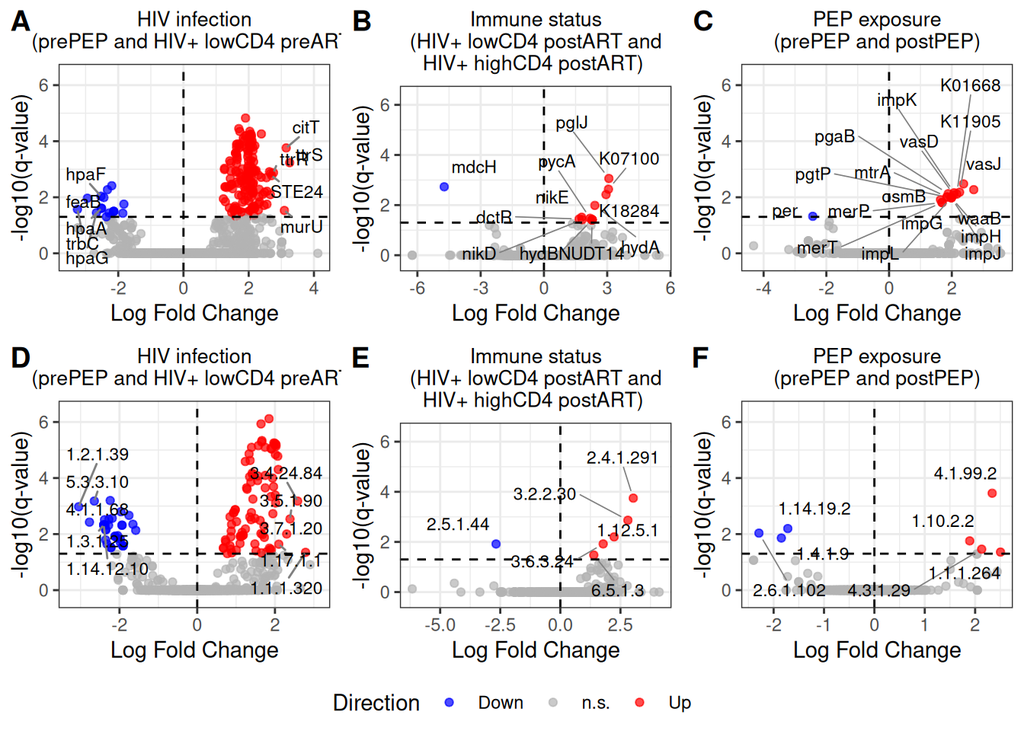

```r
# svg("figures/differential_functions.svg", width = 10.5, height = 7.5)

y_lim <- ggplot_build(f4D)$layout$panel_params[[1]]$y.range
f4Ay <- f4A + coord_cartesian(ylim = y_lim)
f4By <- f4B + coord_cartesian(ylim = y_lim)
f4Cy <- f4C + coord_cartesian(ylim = y_lim)
f4Dy <- f4D + coord_cartesian(ylim = y_lim)
f4Ey <- f4E + coord_cartesian(ylim = y_lim)
f4Fy <- f4F + coord_cartesian(ylim = y_lim)

ggpubr::ggarrange(
    f4Ay, f4By, f4Cy, f4Dy, f4Ey, f4Fy,
    ncol = 3, nrow = 2,
    labels = c("A", "B", "C", "D", "E", "F"),
    common.legend = TRUE,
    legend = "bottom"
)
```

```r
# dev.off()
```

# Reproducibility information